# RNN

### Section B CA1 RNN

Name: Jovan Heng Ghim Hong

Class: DAAA/2B/22

Admin No: 2401418

```python
import tensorflow as tf

gpus = tf.config.experimental.list_physical_devices('GPU')
if gpus:
    try:
        for gpu in gpus:
            tf.config.experimental.set_memory_growth(gpu, True)
    except RuntimeError as e:
        print(e)
```

```python
import os
import pandas as pd
import numpy as np
import pickle
import matplotlib.pyplot as plt
import warnings
import random
import re
import itertools
import gc
import math

from tensorflow.keras.preprocessing.sequence import pad_sequences
from tensorflow.keras.preprocessing.text import Tokenizer
from tensorflow.keras.layers import Dense , Dropout, LSTM, GRU, SimpleRNN, Embedding, BatchNormalization, Bidirectional
from tensorflow.keras.optimizers import Adam
from tensorflow.keras.callbacks import EarlyStopping, ReduceLROnPlateau, ModelCheckpoint
from tensorflow.keras.models import Sequential
from tensorflow.keras.metrics import RootMeanSquaredError
from tensorflow.keras import backend as K
from sklearn.model_selection import train_test_split, ParameterGrid
from sklearn.feature_extraction.text import TfidfVectorizer
from sklearn.metrics import pairwise_distances_argmin_min
from sklearn.cluster import KMeans
from sklearn.decomposition import TruncatedSVD

import nltk
from nltk.stem import WordNetLemmatizer
from nltk.tokenize import word_tokenize
from nltk import pos_tag
from nltk.corpus import wordnet, stopwords
from nltk.tokenize.treebank import TreebankWordDetokenizer
from scipy.sparse  import hstack

nltk.download('punkt_tab')
nltk.download('wordnet')
nltk.download('averaged_perceptron_tagger')
nltk.download('omw-1.4')
nltk.download('averaged_perceptron_tagger_eng')
nltk.download('stopwords')

np.random.seed(42)
tf.random.set_seed(42)
random.seed(42)
warnings.filterwarnings('ignore')
```

```python
df = pd.read_csv(os.path.join('datasets' , 'Movie reviews.csv'))
```

##### Basic Data Exploration

```python
df
```

|  | Review | Score | Are there ways for you to generate more data? Spliting up sentences, would that help? | Language |
| --- | --- | --- | --- | --- |
| 0 | Filem ini hebat! Aksi yang mendebarkan dan plo... | 0.1 | NaN | Malay |
| 1 | Filem ini hebat! Aksi yang mendebarkan dan plo... | 0.9 | NaN | Malay |
| 2 | Filem ini hebat! Aksi yang mendebarkan dan plo... | 0.5 | NaN | Malay |
| 3 | Sayang sekali, pelakon tidak memberikan persem... | 0.8 | NaN | Malay |
| 4 | Jalan cerita yang kompleks dan penuh emosi. Su... | 0.2 | NaN | Malay |
| ... | ... | ... | ... | ... |
| 522 | Pening | 0.7 | NaN | Malay |
| 523 | Berkesan | 0.2 | NaN | Malay |
| 524 | Mengujakan | 0.1 | NaN | Malay |
| 525 | Sederhana and teruk | 0.6 | NaN | Malay |
| 526 | Sempurna | 0.1 | NaN | Malay |

527 rows × 4 columns

```python
df.info()
```

```
<class 'pandas.core.frame.DataFrame'>
RangeIndex: 527 entries, 0 to 526
Data columns (total 4 columns):
 #   Column                                                                                 Non-Null Count  Dtype
---  ------                                                                                 --------------  -----
 0   Review                                                                                 527 non-null    object
 1   Score                                                                                  525 non-null    float64
 2   Are there ways for you to generate more data? Spliting up sentences, would that help?  0 non-null      float64
 3   Language                                                                               527 non-null    object
dtypes: float64(2), object(2)
memory usage: 16.6+ KB
```

Col index 2 is a hint not actual usable data

Hint: **Are there ways for you to generate more data? Spliting up sentences, would that help?**

```python
df.drop(columns='Are there ways for you to generate more data? Spliting up sentences, would that help?', inplace=True)
```

```python
df['Language'].unique()
```

```
array(['Malay', 'English', 'Chinese', 'Nippon'], dtype=object)
```

```python
# Note sure what Nippon is
df[df['Language'] == 'Nippon']
```

|  | Review | Score | Language |
| --- | --- | --- | --- |
| 484 | Nani kore | 0.997413 | Nippon |

Looks like **Nippon** is **Japanese**, **Nani Kore** roughly translating to **What's This?** (condescendingly)

```python
df.iloc[0:3]
```

|  | Review | Score | Language |
| --- | --- | --- | --- |
| 0 | Filem ini hebat! Aksi yang mendebarkan dan plo... | 0.1 | Malay |
| 1 | Filem ini hebat! Aksi yang mendebarkan dan plo... | 0.9 | Malay |
| 2 | Filem ini hebat! Aksi yang mendebarkan dan plo... | 0.5 | Malay |

These 3 have the same review but different score

```python
df.iloc[0]['Review']
```

```
'Filem ini hebat! Aksi yang mendebarkan dan plot yang mengejutkan.'
```

Acoording to **Google Translate** this roughly translates to *This movie is great! Thrilling action and a surprising plot*

##### Trying to figure out what **Score** means

```python
df[(df['Language'] == 'English') & (df['Score'] > 0.75)]
```

|  | Review | Score | Language |
| --- | --- | --- | --- |
| 212 | Avengers: Endgame is disappointing and too cli... | 0.85 | English |
| 219 | I'm not satisfied with how the main actors del... | 0.80 | English |
| 236 | This film is very disappointing. Not worth the... | 0.80 | English |
| 262 | Lack of character development makes this film ... | 0.80 | English |
| 294 | This film is highly disappointing. It fails to... | 0.80 | English |
| 430 | Disappointing | 0.80 | English |
| 472 | Disappointing resolution | 0.80 | English |

```python
df[(df['Language'] == 'English') & (df['Score'] < 0.25)]
```

|  | Review | Score | Language |
| --- | --- | --- | --- |
| 206 | This movie is amazing! The action is breathtak... | 0.08 | English |
| 208 | The storyline is touching and full of emotion.... | 0.12 | English |
| 209 | This movie delivers an outstanding experience.... | 0.05 | English |
| 211 | I'm thrilled throughout the movie. Engaging st... | 0.15 | English |
| 214 | This film is truly impressive with deep emotio... | 0.12 | English |
| ... | ... | ... | ... |
| 501 | Visually stunning, emotionally resonant journey | 0.08 | English |
| 502 | Compelling story, outstanding performances | 0.12 | English |
| 503 | Intricate plot, unexpected twists | 0.10 | English |
| 505 | Breathtaking visuals, engaging narrative | 0.08 | English |
| 506 | Top-notch effects, captivating storytelling | 0.08 | English |

201 rows × 3 columns

Contrary to what may be expected, **a lower score actually represents more positive reviews**

Therefore score can roughly be defined as **How much I dislike this movie**.

Likewise rows with missing scores can be infered as **un-sentimental review** (like just stopwords or generic words)

```python
df[df['Score'].isnull()]
```

|  | Review | Score | Language |
| --- | --- | --- | --- |
| 426 | Ni hao | NaN | Chinese |
| 493 | Diabolic | NaN | English |

```python
# We can drop the missing score cols
df.dropna(inplace=True)
df.info()
```

```
<class 'pandas.core.frame.DataFrame'>
Index: 525 entries, 0 to 526
Data columns (total 3 columns):
 #   Column    Non-Null Count  Dtype
---  ------    --------------  -----
 0   Review    525 non-null    object
 1   Score     525 non-null    float64
 2   Language  525 non-null    object
dtypes: float64(1), object(2)
memory usage: 16.4+ KB
```

```python
## Looking at chinese reviews
df[df['Language'] == 'Chinese']
```

|  | Review | Score | Language |
| --- | --- | --- | --- |
| 427 | Hen tai fei chang hao | 0.001 | Chinese |

```python
df[df['Language'] == 'Malay']
```

|  | Review | Score | Language |
| --- | --- | --- | --- |
| 0 | Filem ini hebat! Aksi yang mendebarkan dan plo... | 0.1 | Malay |
| 1 | Filem ini hebat! Aksi yang mendebarkan dan plo... | 0.9 | Malay |
| 2 | Filem ini hebat! Aksi yang mendebarkan dan plo... | 0.5 | Malay |
| 3 | Sayang sekali, pelakon tidak memberikan persem... | 0.8 | Malay |
| 4 | Jalan cerita yang kompleks dan penuh emosi. Su... | 0.2 | Malay |
| ... | ... | ... | ... |
| 522 | Pening | 0.7 | Malay |
| 523 | Berkesan | 0.2 | Malay |
| 524 | Mengujakan | 0.1 | Malay |
| 525 | Sederhana and teruk | 0.6 | Malay |
| 526 | Sempurna | 0.1 | Malay |

226 rows × 3 columns

```python
df[df['Language'] == 'English']
```

|  | Review | Score | Language |
| --- | --- | --- | --- |
| 206 | This movie is amazing! The action is breathtak... | 0.08 | English |
| 207 | I'm disappointed with the actors' performance.... | 0.70 | English |
| 208 | The storyline is touching and full of emotion.... | 0.12 | English |
| 209 | This movie delivers an outstanding experience.... | 0.05 | English |
| 210 | Too many action scenes, sometimes unnecessary.... | 0.40 | English |
| ... | ... | ... | ... |
| 502 | Compelling story, outstanding performances | 0.12 | English |
| 503 | Intricate plot, unexpected twists | 0.10 | English |
| 504 | Underwhelming moments, weak characterizations | 0.60 | English |
| 505 | Breathtaking visuals, engaging narrative | 0.08 | English |
| 506 | Top-notch effects, captivating storytelling | 0.08 | English |

297 rows × 3 columns

```python
df = df[~df['Language'].isin(['Chinese', 'Japanese'])]
```

Looking at duplicates

```python
# View Duplicated Columns
df[df.duplicated(subset='Review' , keep=False)]
```

|  | Review | Score | Language |
| --- | --- | --- | --- |
| 0 | Filem ini hebat! Aksi yang mendebarkan dan plo... | 0.10 | Malay |
| 1 | Filem ini hebat! Aksi yang mendebarkan dan plo... | 0.90 | Malay |
| 2 | Filem ini hebat! Aksi yang mendebarkan dan plo... | 0.50 | Malay |
| 16 | Jalan cerita yang rumit tetapi sangat menarik.... | 0.20 | Malay |
| 18 | Filem ini benar-benar membuat saya terbawa sua... | 0.10 | Malay |
| ... | ... | ... | ... |
| 433 | Impressive | 0.08 | English |
| 442 | Complex | 0.10 | English |
| 446 | Intriguing | 0.12 | English |
| 447 | Moving | 0.12 | English |
| 448 | Weak | 0.50 | English |

213 rows × 3 columns

Since we have both Malay and English, we will **translate the malay reviews to english**

It will regress on the scores, trying to predict the sentiment for future/new data

```python
from deep_translator import GoogleTranslator
import time

def translate_malay_to_english(text, max_retries=3):
    for attempt in range(max_retries):
        try:
            translator = GoogleTranslator(source='ms', target='en')
            translated = translator.translate(text)
            return translated if translated else text
        except:
            time.sleep(2)  # Simple delay between retries
    return text  # Return original if all retries fail

# Apply translation to Malay reviews
df_malay = df[df['Language'] == 'Malay'].copy()
df_malay['Review'] = df_malay['Review'].apply(translate_malay_to_english)
df_malay['Language'] = 'English'

# Combine with English reviews
df_english = pd.concat([df[df['Language'] == 'English'], df_malay], ignore_index=True)
```

##### What to do with duplicated reviews?

Currently there are some reviews (shown earlier in cell 13) where they are the **exact same review but with different scores**

**Why not take mean?**

As shown below, taking the mean will result in a score of 0.5

[figure not shown]

This does not reflect on what the actual review means *('This movie is great! Thrilling action and a surprising plot')*

##### What do we do??

Simply we can drop all of the duplicated review, this prevents inconsistencies *(like shown above)* from affecting our data.

```python
df_english = df_english.drop_duplicates(subset='Review').reset_index(drop=True)
```

##### Anamoly Detection

As nature of language, **sarcasm** exists.

To detect this we can cluster the sentiments against the TF-IDF vectorization.

This allows us to detect any 'sarcasm' within our dataset.

```python
tfidf_vectorizer = TfidfVectorizer()
tfidf_matrix = tfidf_vectorizer.fit_transform(df_english['Review'])
```

```python
features = hstack([tfidf_matrix , df_english['Score'].values.reshape(-1 , 1)])
```

```python
kmeans = KMeans(n_clusters=2 , random_state=42)
kmeans.fit(features)
```

```
KMeans(n_clusters=2, random_state=42)
```

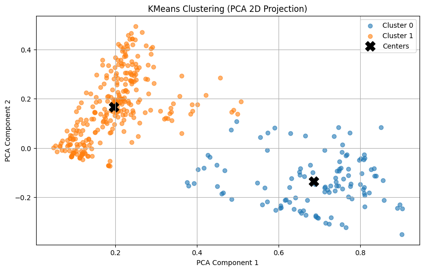

```python
# plotting it
trunc = TruncatedSVD(n_components=2 , random_state=42)
features_2d = trunc.fit_transform(features)

labels = kmeans.labels_


plt.figure(figsize=(10, 6))

for i in range(2):
    cluster_points = features_2d[labels == i]
    plt.scatter(cluster_points[:, 0], cluster_points[:, 1], label=f"Cluster {i}", alpha=0.6)

# Optional: Plot cluster centers
centers_2d = trunc.transform(kmeans.cluster_centers_)
plt.scatter(centers_2d[:, 0], centers_2d[:, 1], c='black', marker='X', s=200, label='Centers')

plt.title("KMeans Clustering (PCA 2D Projection)")
plt.xlabel("PCA Component 1")
plt.ylabel("PCA Component 2")
plt.legend()
plt.grid(True)
plt.show()
```

```python
# Compute distance from each point to its assigned cluster center
closest, distances = pairwise_distances_argmin_min(features, kmeans.cluster_centers_)
```

```python
df_english['Cluster'] = kmeans.labels_
df_english['DistanceToCenter'] = distances

top_5_percent = round(len(df_english) * 0.05)

# Sort within each cluster to find outliers
outliers = df_english.sort_values(by='DistanceToCenter', ascending=False)
```

```python
for i, row in outliers.head(top_5_percent).iterrows():
    print(f"\n[Cluster {row['Cluster']} | Distance: {row['DistanceToCenter']:.3f} | Score: {row['Score']}]")
    print(row['Review'])
```

```
[Cluster 0 | Distance: 1.069 | Score: 0.99]
Sad

[Cluster 0 | Distance: 1.041 | Score: 0.4]
Overwhelming

[Cluster 0 | Distance: 1.035 | Score: 0.4]
Impactful

[Cluster 0 | Distance: 1.028 | Score: 0.4]
Overwhelming action

[Cluster 0 | Distance: 1.027 | Score: 0.8]
Stir

[Cluster 1 | Distance: 1.027 | Score: 0.2]
Blame

[Cluster 1 | Distance: 1.027 | Score: 0.2]
Effective

[Cluster 1 | Distance: 1.027 | Score: 0.2]
Adorable

[Cluster 1 | Distance: 1.027 | Score: 0.2]
Tempting

[Cluster 0 | Distance: 1.026 | Score: 0.4]
Impactful moments

[Cluster 0 | Distance: 1.024 | Score: 0.5]
Inconsistent

[Cluster 1 | Distance: 1.024 | Score: 0.1]
Rock

[Cluster 1 | Distance: 1.024 | Score: 0.1]
Fabulous

[Cluster 1 | Distance: 1.024 | Score: 0.1]
Perfect

[Cluster 1 | Distance: 1.024 | Score: 0.1]
Entertain

[Cluster 1 | Distance: 1.023 | Score: 0.05]
Masterpiece

[Cluster 1 | Distance: 1.023 | Score: 0.06]
Mesmerizing

[Cluster 1 | Distance: 1.023 | Score: 0.2]
Emotion

[Cluster 1 | Distance: 1.022 | Score: 0.1]
Exhilarating

[Cluster 1 | Distance: 1.022 | Score: 0.1]
Exciting
```

##### Results

The top "anomalous" reviews shows a mapping of **adjectives to its sentiment score**

This is really good data for the RNN, it down right tells my model **what adjectives to look out for** in positive and negative reviews

**However**, we want to see the **full reviews that are most anomalous**

I basically just manually scrolled through the DataFrame until i found the start of those reviews

This can be done easily with the DatraWrangler extension in VScode

```python
outliers.tail(393 - 102)
```

|  | Review | Score | Language | Cluster | DistanceToCenter |
| --- | --- | --- | --- | --- | --- |
| 276 | Excessive and shocking action scenes. Sometime... | 0.40 | English | 0 | 0.998790 |
| 60 | The abundance of action scenes is exhilarating... | 0.30 | English | 1 | 0.998789 |
| 270 | Breathtaking visuals, engaging narrative | 0.08 | English | 1 | 0.998711 |
| 224 | Underwhelming moments | 0.60 | English | 0 | 0.997425 |
| 79 | The actors struggle to embody their characters... | 0.70 | English | 0 | 0.996575 |
| ... | ... | ... | ... | ... | ... |
| 333 | Visual Effects and the design of this movie is... | 0.10 | English | 1 | 0.921784 |
| 129 | The performances of the cast in Avengers: Endg... | 0.12 | English | 1 | 0.921219 |
| 350 | The visual quality of this movie is amazing. E... | 0.10 | English | 1 | 0.915730 |
| 324 | Visual Effects and the animation of this movie... | 0.10 | English | 1 | 0.915342 |
| 0 | This movie is amazing! The action is breathtak... | 0.08 | English | 1 | 0.908870 |

291 rows × 5 columns

##### Key Takeaways

1. The range of positive, neutral and negative reviews **are not equal**

e.g.

*'Underwhelming moments'* has a score of 0.6.

Underwhelming moments is clearly a **light negative review**, suggesting that 0.6 might be the **'start of negative reviews'**

*'The abundance of action scenes is exhilarating. A bit overwhelming at times.'* has a score of 0.3

'exhilarating' suggest positive, but it is lightly critiqued with 'A bit overwhelming at times'. This suggests that this can be a **lightly positive - neutral** review. Therefore 0.3 might be the **'point between positive and neutral reviews'**

*'Excessive and shocking action scenes. Sometimes it's too much.'*

The sentence structure suggests that this is a **'neutral review'** and it has a score of 0.4, which falls into our 'predicted range' of sentiments

2. There are some mislabelled reviews

**indexes: [4 , 342]**

e.g.

'Too many action scenes, sometimes unnecessary. Too dramatic.' has a score of 0.4

This is clearly a negative review. Eventhouugh 'sometimes' softens the blow, it should not be classified as 'neutral' but 'negative'

3. "Plot Twist"

**index: [246]**

It was labelled with a score of 0.7, with is 'negative'

But "Plot Twist" is **Context dependent** and on its own it is just Neutral.

```python
df_english.at[246 , 'Score'] = 0.5
df_english.at[4 , 'Score'] = 0.65
df_english.at[342 , 'Score'] = 0.65
```

##### Data Engineering

Currently our data is too little to train a NN. We need to force out more data from this dataset

##### How to Force

1. We will split sentences into clauses, **usually seperated via punctuation**

e.g.

> This movie is amazing! The action is breathtaking, and the plot is intriguing.

can become:

> This movie is amazing!

> The action is breathtaking

> the plot is intriguing

We can assign new scores to each subsentence

2. From the Clauses we can **Join with Conjunctions**

e.g.

> This movie is amazing!

> The action is breathtaking

can become:

> The movie is amazing and the action is breathtaking.
3. We can perform **sentence shuffling around a conjunction**

e.g.

> The movie is amazing and the action is breathtaking.

can become:

> The action is breathtaking and the movie is amazing.
4. We can **Create artificial Reviews**

e.g.

> The movie is <adj1> and the action is <adj2>

can become:

> The movie is astonishing and the action is spectacular

We can use the 'key value paired' adjectives (mentioned above during anomaly detection) as a *'word bank'* to find such adjectives

5.. We can **Join artificially created Reviews together**

This is similiar to **Joining around Conjunction**

```python
def get_clauses(df):
  reviews = df['Review']
  scores = df['Score']

  results = pd.DataFrame({
    'Review': [], 'Score': []
  })

  # sub clauses
  for review, score in zip(reviews , scores):

    # this subclausing assumes that all clauses are roughly the same sentiment (all pos or all neg)
    # we ignore neutral classes
    if 0.3 < score and score < 0.6:
      continue

    total_words = len(review.split(' '))

    clauses = re.split(r'[.?!,]' , review.strip())

    cleaned_clauses = [c.strip() for c in clauses if c != '']

    # remove additional 'and'
    for i in range(len(cleaned_clauses)):
      if cleaned_clauses[i].strip().startswith('and'):
        cleaned_clauses[i] = cleaned_clauses[i].strip()[3:]

      # This isn't grammatically correct but incase
      if cleaned_clauses[i].strip().endswith('and'):
        cleaned_clauses[i] = cleaned_clauses[i].strip()[:-3]


    for i , clause in enumerate(cleaned_clauses):
      clause = clause.strip() # remove additional whitespace
      multiplier = len(clause.split(' ')) / total_words

      results = pd.concat([results,
                 pd.DataFrame({
                    'Review': [clause],
                    'Score': [score * multiplier]
                 })
      ], ignore_index=True)


      # clause join and rotation about conjunction
      if i != len(cleaned_clauses) -1:
        conjuction_clauses = [f'{clause} and {cleaned_clauses[i + 1]}' ,f'{cleaned_clauses[i + 1]} and {clause}' ]
        multiplier = (len(clause.split(' ')) + len(cleaned_clauses[i + 1].split(' '))) / total_words

        results = pd.concat([results,
                   pd.DataFrame({
                      'Review': conjuction_clauses,
                      'Score': [score * multiplier] * 2
                   })
        ], ignore_index=True)
  return results.dropna().drop_duplicates(subset='Review')
```

```python
def artificial_review_creation(adjective_dictionary):
  pos_templates = [
    'The movie was really <adj>!',
    'I really liked the action, it was <adj>',
    'Such an experience! The scenes were <adj>.',
    'I found the action to be <adj>',
    'The pacing was refreshingly <adj> throughout the film!',
    'The characters were incredibly <adj> and engaging.',
    'The plot progression felt smooth and <adj>.',
    'I thought the ending was particularly <adj>.',
    'The performances were truly <adj>.',
    'The soundtrack was absolutely <adj>.',
    'The dialogues felt very <adj> and natural.',
    'Direction-wise, the movie was quite <adj>.',
    'Everything about the film came together in a <adj> way.',
    'From start to finish, it felt <adj>.',
    'The editing was impressively <adj> and clean.',
    'The overall tone was consistent and <adj>.',
    'Several scenes stood out for being especially <adj>.',
    'Honestly, the entire movie felt <adj>.',
    'I was surprised by how <adj> it all felt!',

    # more generic ones
    'The storytellling was <adj>',
    'The visuals were <adj>',
    'The film was <adj>',
  ]

  neg_templates = [
    'The movie was really <adj>',
    'I found the scenese to be <adj>',
    'Honestly, i really found the action scenes to be <adj>',
    'The experience was <adj>, i did not like it',
    'The pacing felt <adj> throughout the film',
    'Character development was quite <adj>',
    'The plot progression was <adj> and hard to follow',
    'I thought the ending was especially <adj>',
    'Most of the performances were <adj>',
    'The soundtrack was just <adj>',
    'Dialogue in many scenes came off as <adj>',
    'The direction was surprisingly <adj>',
    'Everything about the film just seemed <adj>',
    'To me, it all felt very <adj>',
    'At times, the editing became <adj> and distracting',
    'The tone of the film stayed <adj> from start to finish',
    'Some scenes were painfully <adj>',
    'Unfortunately, the entire movie felt <adj>',

    # more generic ones
    'The storytellling was <adj>',
    'The visuals were <adj>',
    'The film was <adj>',
  ]

  # prevent grey area (0.3 - 0.6) which are mix of pos and neg (more generic in sentence context but harder to template into)
  pos_margin = 0.3
  neg_margin = 0.6

  reviews = []
  scores = []
  for adj , score in adjective_dictionary.items():
    if score <= pos_margin:
      for template in pos_templates:
        review = template.replace('<adj>' , adj)
        reviews.append(review)
        scores.append(score)


    if score >= neg_margin:
      for template in neg_templates:
        review = template.replace('<adj>' , adj)
        reviews.append(review)
        scores.append(score)


  return pd.DataFrame({
    'Review': reviews,
    'Score': scores
  }).dropna().drop_duplicates(subset='Review')
```

```python
def join_reviews(df):
    pos_df = df[df['Score'] <= 0.3].reset_index(drop=True)
    neutral_df = df[(df['Score'] > 0.3) & (df['Score'] < 0.6)].reset_index(drop=True)
    neg_df = df[df['Score'] >= 0.6].reset_index(drop=True)

    joined_reviews = []
    joined_scores = []

    for sentiment_df in [pos_df, neutral_df, neg_df]:
        for (i1, row1), (i2, row2) in itertools.combinations(sentiment_df.iterrows(), 2):
            combined_review = f"{row1['Review']} {row2['Review']}"
            avg_score = round((row1['Score'] + row2['Score']) / 2, 3)
            joined_reviews.append(combined_review)
            joined_scores.append(avg_score)

    return pd.DataFrame({
        'Review': joined_reviews,
        'Score': joined_scores
    })
```

```python
def create_neutral_reviews(adjective_list):
# logic for generating neutral reviews will be different
  positive_adj = [k for k , v in adjective_list.items() if v <= 0.3]
  negative_adj = [k for k , v in adjective_list.items() if v >= 0.6]

  # notice how these can be used under 'get_clauses
  templates = [
    'The action is <adj1>, but the story telling was <adj2>',
    'The visuals were <adj1>, but some parts were <adj2>',
    'The film was <adj1>, but sometimes it feels like <adj2>',
    'While it is <adj1>, it also is somewhat <adj2>, so the result is average',
  ]
  # map every pos to every neg
  reviews = []
  scores = []
  for pos_adj in positive_adj:
    for neg_adj in negative_adj:
      for template in templates:
        review1 = template.replace('<adj1>' , pos_adj).replace('<adj2>' , neg_adj)

        # we can replace the positions to create a new review
        review2 = template.replace('<adj1>' , pos_adj).replace('<adj2>' , neg_adj)
        reviews.append(review1)
        reviews.append(review2)

        avg_score = (adjective_list[pos_adj] + adjective_list[neg_adj]) / 2
        # append twice for 2 reviews
        scores.append(avg_score)
        scores.append(avg_score)

  return pd.DataFrame({
    'Review': reviews,
    'Score': scores
  }).dropna().drop_duplicates(subset='Review')
```

First thing is to **train_test_split** the raw data, this prevents **data leakage**

##### Creating 'Classes'

When i train-test-split my data, i want it to be somewhat stratified

A way that i can achieve this is to **label my data**, allowing me to stratify when i split the data.

##### How to split

As observered above, there are some adjectives - score *'key value pairs'*

This is **crucial data for my RNN** as such i should remove it and use it inside of my **train data**

```python
def create_label(score):
  if score >= 0.6:
    return 0
  elif score >= 0.35:
    return 1
  else:
    return 2
# 0 neg , 1 neutral , 2 pos
```

```python
df_english['Review Type'] = df_english['Score'].apply(create_label)
```

```python
df_english
```

|  | Review | Score | Language | Cluster | DistanceToCenter | Review Type |
| --- | --- | --- | --- | --- | --- | --- |
| 0 | This movie is amazing! The action is breathtak... | 0.08 | English | 1 | 0.908870 | 2 |
| 1 | I'm disappointed with the actors' performance.... | 0.70 | English | 0 | 0.964013 | 0 |
| 2 | The storyline is touching and full of emotion.... | 0.12 | English | 1 | 0.959562 | 2 |
| 3 | This movie delivers an outstanding experience.... | 0.05 | English | 1 | 0.971211 | 2 |
| 4 | Too many action scenes, sometimes unnecessary.... | 0.65 | English | 0 | 0.983934 | 0 |
| ... | ... | ... | ... | ... | ... | ... |
| 388 | Dizzy | 0.70 | English | 0 | 1.018202 | 0 |
| 389 | Effective | 0.20 | English | 1 | 1.026562 | 2 |
| 390 | Exciting | 0.10 | English | 1 | 1.021941 | 2 |
| 391 | Moderate and severe | 0.60 | English | 0 | 1.013062 | 0 |
| 392 | Perfect | 0.10 | English | 1 | 1.023761 | 2 |

393 rows × 6 columns

```python
# selecting my 'adjective list'
adjective_list = df_english[df_english['Review'].str.split(' ').str.len() <= 2]
adjective_list
```

|  | Review | Score | Language | Cluster | DistanceToCenter | Review Type |
| --- | --- | --- | --- | --- | --- | --- |
| 175 | Masterpiece | 0.05 | English | 1 | 1.023424 | 2 |
| 176 | Spectacular | 0.08 | English | 1 | 1.017513 | 2 |
| 177 | Emotional | 0.07 | English | 1 | 1.003996 | 2 |
| 178 | Epic | 0.06 | English | 1 | 1.009145 | 2 |
| 179 | Thrilling | 0.10 | English | 1 | 1.011943 | 2 |
| ... | ... | ... | ... | ... | ... | ... |
| 387 | Adorable | 0.20 | English | 1 | 1.026562 | 2 |
| 388 | Dizzy | 0.70 | English | 0 | 1.018202 | 0 |
| 389 | Effective | 0.20 | English | 1 | 1.026562 | 2 |
| 390 | Exciting | 0.10 | English | 1 | 1.021941 | 2 |
| 392 | Perfect | 0.10 | English | 1 | 1.023761 | 2 |

102 rows × 6 columns

```python
splitable_reviews = df_english[~df_english.index.isin(adjective_list.index)]
splitable_reviews
```

|  | Review | Score | Language | Cluster | DistanceToCenter | Review Type |
| --- | --- | --- | --- | --- | --- | --- |
| 0 | This movie is amazing! The action is breathtak... | 0.08 | English | 1 | 0.908870 | 2 |
| 1 | I'm disappointed with the actors' performance.... | 0.70 | English | 0 | 0.964013 | 0 |
| 2 | The storyline is touching and full of emotion.... | 0.12 | English | 1 | 0.959562 | 2 |
| 3 | This movie delivers an outstanding experience.... | 0.05 | English | 1 | 0.971211 | 2 |
| 4 | Too many action scenes, sometimes unnecessary.... | 0.65 | English | 0 | 0.983934 | 0 |
| ... | ... | ... | ... | ... | ... | ... |
| 373 | The movie is really impressive with a deep emo... | 0.12 | English | 1 | 0.960357 | 2 |
| 374 | Surprising action and shocking plot. I'm impre... | 0.12 | English | 1 | 0.976276 | 2 |
| 375 | I am dissatisfied with the way the main actor ... | 0.80 | English | 0 | 0.978241 | 0 |
| 376 | Complex but very interesting storyline. I love... | 0.20 | English | 1 | 0.981517 | 2 |
| 391 | Moderate and severe | 0.60 | English | 0 | 1.013062 | 0 |

291 rows × 6 columns

60-20-20 split

```python
X_train, X_test, y_train, y_test = train_test_split(splitable_reviews['Review'] , splitable_reviews['Score'] , train_size=0.8 , random_state=42, stratify=splitable_reviews['Review Type'])
```

```python
X_train , X_val , y_train , y_val= train_test_split(X_train, y_train, train_size=0.75, random_state=42, stratify=splitable_reviews.loc[X_train.index, 'Review Type'])
```

##### Data Augmentation

reformat some of the data for us to work with

```python
augmentable_df = pd.DataFrame({
  'Review': X_train.values,
  'Score': y_train.values,
})
```

```python
adjective_list_dict = dict(zip(adjective_list['Review'].str.lower() , adjective_list['Score']))
```

```python
adjective_list_dict
```

```
{'masterpiece': 0.05,
 'spectacular': 0.08,
 'emotional': 0.07,
 'epic': 0.06,
 'thrilling': 0.1,
 'compelling': 0.12,
 'underwhelming': 0.6,
 'intriguing': 0.15,
 'touching': 0.1,
 'mesmerizing': 0.06,
 'flat': 0.65,
 'exhilarating': 0.1,
 'impressive': 0.08,
 'inconsistent': 0.5,
 'breathtaking': 0.08,
 'outstanding': 0.12,
 'complex': 0.65,
 'surprising': 0.1,
 'unsatisfying': 0.7,
 'moving': 0.12,
 'incredible': 0.08,
 'weak': 0.75,
 'great': 0.08,
 'overwhelming': 0.4,
 'confusing': 0.7,
 'captivating': 0.12,
 'top-notch': 0.08,
 'disappointing': 0.8,
 'challenging': 0.65,
 'intense': 0.1,
 'missed': 0.75,
 'entertaining': 0.12,
 'over-the-top': 0.4,
 'twist': 0.7,
 'striking': 0.12,
 'ordinary': 0.65,
 'amazing': 0.12,
 'engaging': 0.06,
 'unconvincing': 0.75,
 'enriching': 0.13,
```

[output cut: 47 more lines]

```
 'tempting': 0.2,
 'sad': 0.99,
 'blame': 0.2,
 'emotion': 0.2,
 'entertain': 0.1,
 'unsatisfactory': 0.7,
 'rock': 0.1,
 'epic hiking': 0.1,
 'fabulous': 0.1,
 'stir': 0.8,
 'adorable': 0.2,
 'dizzy': 0.7,
 'effective': 0.2,
 'exciting': 0.1,
 'perfect': 0.1}
```

Creating data

```python
# Create additional data
additional_data_english = get_clauses(augmentable_df)
```

```python
additional_data_english
```

|  | Review | Score |
| --- | --- | --- |
| 0 | The action sequences in Avengers: Endgame are ... | 0.017778 |
| 1 | The action sequences in Avengers: Endgame are ... | 0.048889 |
| 2 | delivering a level of intensity that keeps aud... | 0.048889 |
| 3 | delivering a level of intensity that keeps aud... | 0.031111 |
| 4 | delivering a level of intensity that keeps aud... | 0.064444 |
| ... | ... | ... |
| 968 | The emotional depth of the characters is portr... | 0.070769 |
| 969 | The emotional depth of the characters is portr... | 0.030769 |
| 970 | The emotional depth of the characters is portr... | 0.049231 |
| 971 | creating a connection with the audience and Th... | 0.049231 |
| 972 | creating a connection with the audience | 0.018462 |

924 rows × 2 columns

```python
artificial_reviews = artificial_review_creation(adjective_list_dict)
```

```python
artificial_reviews
```

|  | Review | Score |
| --- | --- | --- |
| 0 | The movie was really masterpiece! | 0.05 |
| 1 | I really liked the action, it was masterpiece | 0.05 |
| 2 | Such an experience! The scenes were masterpiece. | 0.05 |
| 3 | I found the action to be masterpiece | 0.05 |
| 4 | The pacing was refreshingly masterpiece throug... | 0.05 |
| ... | ... | ... |
| 1994 | Honestly, the entire movie felt perfect. | 0.10 |
| 1995 | I was surprised by how perfect it all felt! | 0.10 |
| 1996 | The storytellling was perfect | 0.10 |
| 1997 | The visuals were perfect | 0.10 |
| 1998 | The film was perfect | 0.10 |

1999 rows × 2 columns

```python
# Now we can combine everything together and drop any duplicated rows
train_data_df = pd.concat([
  augmentable_df,
  adjective_list[['Review' , 'Score']] ,
  additional_data_english,
  artificial_reviews
] , ignore_index=True)
```

```python
train_data_df
```

|  | Review | Score |
| --- | --- | --- |
| 0 | The action sequences in Avengers: Endgame are ... | 0.10 |
| 1 | This film is a masterpiece! The storytelling i... | 0.05 |
| 2 | I like the way this movie combines comedy with... | 0.15 |
| 3 | While the main actors deliver commendable perf... | 0.75 |
| 4 | Too many action scenes, sometimes unnecessary.... | 0.65 |
| ... | ... | ... |
| 3194 | Honestly, the entire movie felt perfect. | 0.10 |
| 3195 | I was surprised by how perfect it all felt! | 0.10 |
| 3196 | The storytellling was perfect | 0.10 |
| 3197 | The visuals were perfect | 0.10 |
| 3198 | The film was perfect | 0.10 |

3199 rows × 2 columns

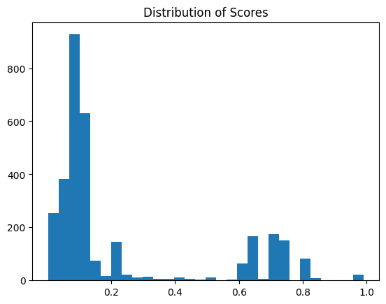

```python
# Checking data proportion
plt.hist(train_data_df['Score'], bins=30)
plt.title('Distribution of Scores')
plt.xticks(np.arange(0.2 , 1.2 , 0.2))
plt.show()
```

The data is very **positively skewed**, this suggests that i need some way to create more neutral and negative data

Ideal distribution:

1. Normal Distribution, with **more neutral reviews** than the rest. This mimicks **real world scenerios** where reviews are more subjective and not as opinion based.
2. Roughly Equally Distributed. This ensures that my data is able to learn from **all different kinds of reviews**. This allows my model to **generalize the best**

For now we can attempt to **increase neutral data**

```python
neutral_data = create_neutral_reviews(adjective_list_dict)
```

```python
neutral_data
```

|  | Review | Score |
| --- | --- | --- |
| 0 | The action is masterpiece, but the story telli... | 0.325 |
| 2 | The visuals were masterpiece, but some parts w... | 0.325 |
| 4 | The film was masterpiece, but sometimes it fee... | 0.325 |
| 6 | While it is masterpiece, it also is somewhat u... | 0.325 |
| 8 | The action is masterpiece, but the story telli... | 0.350 |
| ... | ... | ... |
| 13390 | While it is perfect, it also is somewhat stir,... | 0.450 |
| 13392 | The action is perfect, but the story telling w... | 0.400 |
| 13394 | The visuals were perfect, but some parts were ... | 0.400 |
| 13396 | The film was perfect, but sometimes it feels l... | 0.400 |
| 13398 | While it is perfect, it also is somewhat dizzy... | 0.400 |

6700 rows × 2 columns

```python
train_data_df = pd.concat([
  augmentable_df,
  adjective_list[['Review' , 'Score']] ,
  additional_data_english,
  artificial_reviews,
  neutral_data,
], ignore_index=True).dropna().drop_duplicates(subset='Review')
```

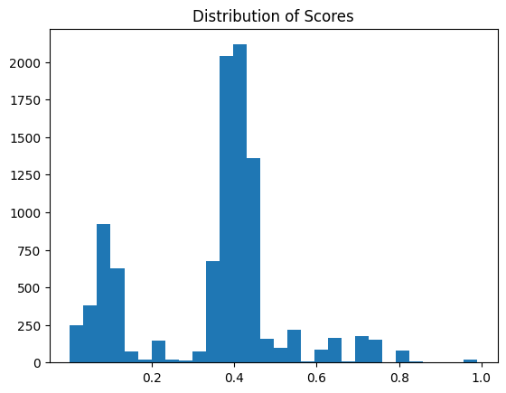

```python
# Checking data proportion
plt.hist(train_data_df['Score'], bins=30)
plt.title('Distribution of Scores')
plt.xticks(np.arange(0.2 , 1.2 , 0.2))
plt.show()
```

We still have very little negative reviews, and now significantly lesser positive reviews

We can try to add our own **adjectives** to our adjective list

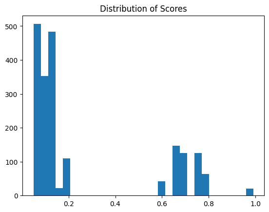

```python
# i plan to join artifical reviews together

plt.hist(artificial_reviews['Score'], bins=30)
plt.title('Distribution of Scores')
plt.xticks(np.arange(0.2 , 1.2 , 0.2))
plt.show()
```

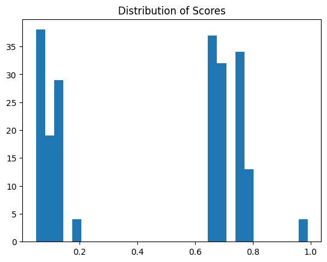

```python
# my artificial data is already quite skewed
# i need to make not-skewed to allow for more negative data overall
neg_1 = artificial_reviews[(artificial_reviews['Score'] >= 0.65)].sample(n = 120, random_state = 42)
pos_1 = artificial_reviews[(artificial_reviews['Score'] <= 0.2)].sample(n = 90 , random_state = 42)
selected_artificial_reviews = pd.concat([neg_1 , pos_1] , ignore_index=True)

plt.hist(selected_artificial_reviews['Score'], bins=30)
plt.title('Distribution of Scores')
plt.xticks(np.arange(0.2 , 1.2 , 0.2))
plt.show()
```

```python
joined_reviews = join_reviews(selected_artificial_reviews)
joined_reviews
```

|  | Review | Score |
| --- | --- | --- |
| 0 | Several scenes stood out for being especially ... | 0.090 |
| 1 | Several scenes stood out for being especially ... | 0.160 |
| 2 | Several scenes stood out for being especially ... | 0.090 |
| 3 | Several scenes stood out for being especially ... | 0.100 |
| 4 | Several scenes stood out for being especially ... | 0.120 |
| ... | ... | ... |
| 11140 | Dialogue in many scenes came off as complex Th... | 0.700 |
| 11141 | Dialogue in many scenes came off as complex Un... | 0.725 |
| 11142 | Most of the performances were disappointing Th... | 0.775 |
| 11143 | Most of the performances were disappointing Un... | 0.800 |
| 11144 | The film was weak characterizations Unfortunat... | 0.775 |

11145 rows × 2 columns

```python
train_data_df = pd.concat([
  augmentable_df,
  adjective_list[['Review' , 'Score']] ,
  additional_data_english,
  artificial_reviews,
  neutral_data,
  joined_reviews
], ignore_index=True).dropna().drop_duplicates(subset='Review')
```

```python
train_data_df
```

|  | Review | Score |
| --- | --- | --- |
| 0 | The action sequences in Avengers: Endgame are ... | 0.100 |
| 1 | This film is a masterpiece! The storytelling i... | 0.050 |
| 2 | I like the way this movie combines comedy with... | 0.150 |
| 3 | While the main actors deliver commendable perf... | 0.750 |
| 4 | Too many action scenes, sometimes unnecessary.... | 0.650 |
| ... | ... | ... |
| 21039 | Dialogue in many scenes came off as complex Th... | 0.700 |
| 21040 | Dialogue in many scenes came off as complex Un... | 0.725 |
| 21041 | Most of the performances were disappointing Th... | 0.775 |
| 21042 | Most of the performances were disappointing Un... | 0.800 |
| 21043 | The film was weak characterizations Unfortunat... | 0.775 |

21037 rows × 2 columns

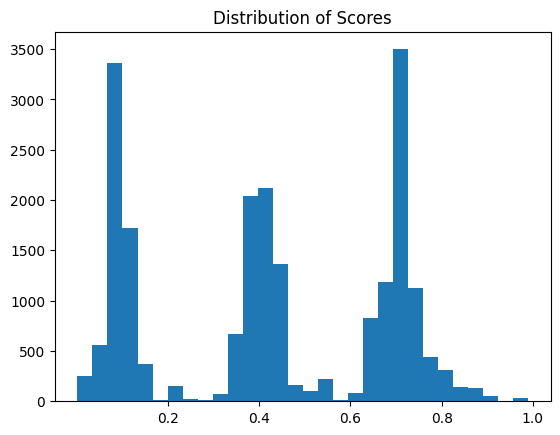

```python
plt.hist(train_data_df['Score'], bins=30)
plt.title('Distribution of Scores')
plt.xticks(np.arange(0.2 , 1.2 , 0.2))
plt.show()
```

Now there aren't as many neutral reviews, we can take the similar approach of 'joining' reviews together

```python
# i need to limit the amount of neutral datas join each other
# sample 33 reviews from each sub-range of neutral scores
neutral_1 = neutral_data[(neutral_data['Score'] >= 0.4) & (neutral_data['Score'] < 0.5)].sample(n=33, random_state=42)
neutral_2 = neutral_data[(neutral_data['Score'] >= 0.5) & (neutral_data['Score'] < 0.6)].sample(n=33, random_state=42)
neutral_3 = neutral_data[(neutral_data['Score'] >= 0.3) & (neutral_data['Score'] < 0.4)].sample(n=33, random_state=42)

select_neutral_reviews = pd.concat([neutral_1, neutral_2, neutral_3], ignore_index=True)
select_neutral_reviews
```

|  | Review | Score |
| --- | --- | --- |
| 0 | The visuals were emotion, but some parts were ... | 0.450 |
| 1 | The visuals were effective, but some parts wer... | 0.425 |
| 2 | The visuals were rock, but some parts were unc... | 0.425 |
| 3 | The film was masterpiece, but sometimes it fee... | 0.400 |
| 4 | While it is epic, it also is somewhat unconvin... | 0.405 |
| ... | ... | ... |
| 94 | The visuals were great, but some parts were ch... | 0.365 |
| 95 | The visuals were complex narrative, but some p... | 0.375 |
| 96 | The visuals were masterpiece, but some parts w... | 0.375 |
| 97 | The film was emotional, but sometimes it feels... | 0.360 |
| 98 | The visuals were enriching storyline, but some... | 0.365 |

99 rows × 2 columns

```python
joined_neutral_reviewe = join_reviews(select_neutral_reviews)
joined_neutral_reviewe
```

|  | Review | Score |
| --- | --- | --- |
| 0 | The visuals were emotion, but some parts were ... | 0.438 |
| 1 | The visuals were emotion, but some parts were ... | 0.438 |
| 2 | The visuals were emotion, but some parts were ... | 0.425 |
| 3 | The visuals were emotion, but some parts were ... | 0.427 |
| 4 | The visuals were emotion, but some parts were ... | 0.427 |
| ... | ... | ... |
| 4846 | The visuals were complex narrative, but some p... | 0.367 |
| 4847 | The visuals were complex narrative, but some p... | 0.370 |
| 4848 | The visuals were masterpiece, but some parts w... | 0.367 |
| 4849 | The visuals were masterpiece, but some parts w... | 0.370 |
| 4850 | The film was emotional, but sometimes it feels... | 0.362 |

4851 rows × 2 columns

```python
train_data_df = pd.concat([
  augmentable_df,
  adjective_list[['Review' , 'Score']] ,
  additional_data_english,
  artificial_reviews,
  neutral_data,
  joined_reviews,
  joined_neutral_reviewe
], ignore_index=True).dropna().drop_duplicates(subset='Review')
```

```python
train_data_df
```

|  | Review | Score |
| --- | --- | --- |
| 0 | The action sequences in Avengers: Endgame are ... | 0.100 |
| 1 | This film is a masterpiece! The storytelling i... | 0.050 |
| 2 | I like the way this movie combines comedy with... | 0.150 |
| 3 | While the main actors deliver commendable perf... | 0.750 |
| 4 | Too many action scenes, sometimes unnecessary.... | 0.650 |
| ... | ... | ... |
| 25890 | The visuals were complex narrative, but some p... | 0.367 |
| 25891 | The visuals were complex narrative, but some p... | 0.370 |
| 25892 | The visuals were masterpiece, but some parts w... | 0.367 |
| 25893 | The visuals were masterpiece, but some parts w... | 0.370 |
| 25894 | The film was emotional, but sometimes it feels... | 0.362 |

25888 rows × 2 columns

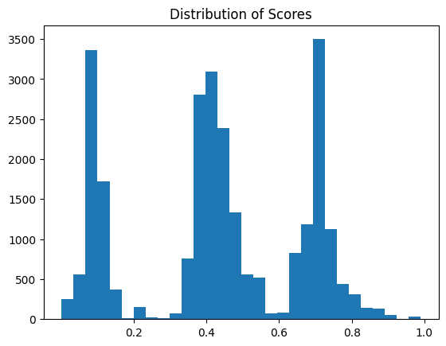

```python
plt.hist(train_data_df['Score'], bins=30)
plt.title('Distribution of Scores')
plt.xticks(np.arange(0.2 , 1.2 , 0.2))
plt.show()
```

My data roughly look trimodal.

Where is seems **normally distributed** around its respectively 'classes'

There is good enough for me to start training my model

we can always add more data later as seems fit

##### Baseline Model

It is important for me to get a rough baseline for what to expect

```python
def create_baseline_model(input_dim , input_length):
  model = Sequential([
    Embedding(input_dim=input_dim, output_dim=256, input_length=input_length),
    LSTM(256, return_sequences=True),
    Dropout(0.5),
    LSTM(128, return_sequences=True),
    Dropout(0.5),
    LSTM(64),
    Dropout(0.5),
    Dense(32, activation='relu'),
    Dropout(0.3),
    Dense(1 , activation='sigmoid')
  ])

  model.compile(loss='mean_squared_error' , optimizer=Adam(learning_rate=5e-3), metrics=['mean_absolute_error' , RootMeanSquaredError('rmse')])
  return model
```

##### Data preprocessing

steps:

1. clean (remove punctuation etc)
2. remove stopwords
3. lemmatize
4. tokenize
5. pad

```python
# Creating val and test as dfs
val_data_df = pd.DataFrame({
  'Review': X_val,
  'Score': y_val
})

test_data_df = pd.DataFrame({
  'Review': X_test,
  'Score': y_test
})
```

```python
def clean_text(text):
  text = text.lower()

  # Remove Punctuation
  text = re.sub(r'[^a-zA-Z\s]', '', text)
  # Remove whitespace
  text = re.sub(r'\s+', ' ', text).strip()

  return text
```

```python
def lemmatize_reviews(x):
  lemmatizer = WordNetLemmatizer()
  words = word_tokenize(x)
  lemmatized_review_words = [lemmatizer.lemmatize(word) for word in words]
  return ' '.join(lemmatized_review_words)
```

```python
def remove_stopwords(x):
  stop_words = set(stopwords.words('english'))
  words = word_tokenize(x)
  filtered = [ w for w in words if w.lower() not in stop_words]
  return ' '.join(filtered)
```

```python
train_data_df['Review'] = train_data_df['Review'].apply(clean_text)
val_data_df['Review'] = val_data_df['Review'].apply(clean_text)
test_data_df['Review'] = test_data_df['Review'].apply(clean_text)
```

```python
train_data_df['Review'] = train_data_df['Review'].apply(remove_stopwords)
val_data_df['Review'] = val_data_df['Review'].apply(remove_stopwords)
test_data_df['Review'] = test_data_df['Review'].apply(remove_stopwords)
```

```python
train_data_df['Lemmatized_Reviews'] = train_data_df['Review'].apply(lemmatize_reviews)
val_data_df['Lemmatized_Reviews'] = val_data_df['Review'].apply(lemmatize_reviews)
test_data_df['Lemmatized_Reviews'] = test_data_df['Review'].apply(lemmatize_reviews)
```

##### Evaluating on base model

```
Epoch 6: ReduceLROnPlateau reducing learning rate to 0.0024999999441206455.
Epoch 26: ReduceLROnPlateau reducing learning rate to 0.0024999999441206455.
```

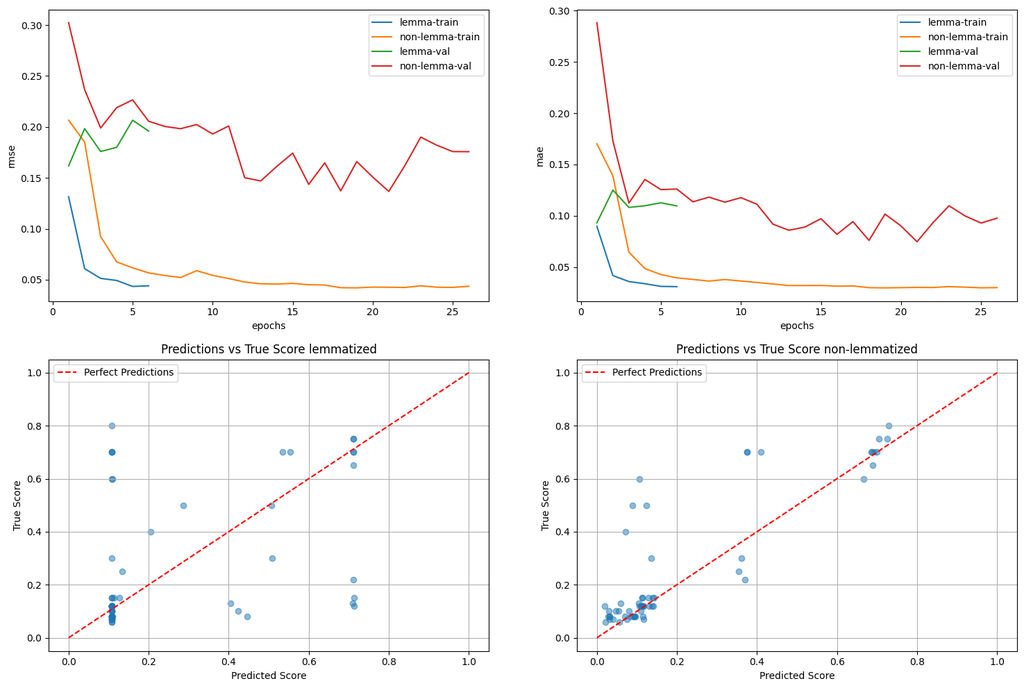

```python
random.seed(42)
# attempting on lemmatized
tokenizer = Tokenizer(oov_token="<OOV>")
tokenizer.fit_on_texts(train_data_df['Lemmatized_Reviews'])
lem_vocab_size = len(tokenizer.word_index) + 1

lem_sequences_train = tokenizer.texts_to_sequences(train_data_df['Lemmatized_Reviews'])
lem_sequences_val = tokenizer.texts_to_sequences(val_data_df['Lemmatized_Reviews'])
lem_sequences_test = tokenizer.texts_to_sequences(test_data_df['Lemmatized_Reviews'])

# attempting on non-lemma
tokenizer = Tokenizer(oov_token="<OOV>")
tokenizer.fit_on_texts(train_data_df['Review'])

sequences_train = tokenizer.texts_to_sequences(train_data_df['Review'])
sequences_val = tokenizer.texts_to_sequences(val_data_df['Review'])
sequences_test = tokenizer.texts_to_sequences(test_data_df['Review'])

# callbacks
early_stopper = EarlyStopping(patience=5 , monitor='val_rmse' , mode='min', restore_best_weights=True)
lr_reducer = ReduceLROnPlateau(
    monitor='val_rmse',
    factor=0.5,
    patience=5,
    min_lr=1e-6,
    verbose=1
)

# padding
lem_max_len = max([len(s) for s in lem_sequences_train])
padded_sequences_lem = pad_sequences(lem_sequences_train, padding='post', maxlen=lem_max_len)
padded_val_sequences_lem = pad_sequences(lem_sequences_val, padding='post' , maxlen=lem_max_len)

non_lem_max_len = max([len(s) for s in sequences_train])
padded_sequences= pad_sequences(sequences_train, padding='post', maxlen=non_lem_max_len)
padded_val_sequences= pad_sequences(sequences_val, padding='post' , maxlen=non_lem_max_len)

# setting up plots
fig , ax = plt.subplots(2 , 2 , figsize=(18 , 12))
ax = ax.flatten()

# Training on lem
baseline_model_lem = create_baseline_model(input_dim=lem_vocab_size, input_length=lem_max_len)
lem_results = baseline_model_lem.fit(padded_sequences_lem, train_data_df['Score'],
            batch_size=32,
            epochs=50,
            validation_data=(padded_val_sequences_lem, val_data_df['Score']),
            verbose = 1,
            callbacks=[early_stopper, lr_reducer]
)

# Train on no lem
baseline_model_no_lem = create_baseline_model(input_dim=lem_vocab_size, input_length=non_lem_max_len)
non_lem_results = baseline_model_no_lem.fit(padded_sequences, train_data_df['Score'],
            batch_size=32,
            epochs=50,
            validation_data=(padded_val_sequences, val_data_df['Score']),
            verbose = 1,
            callbacks=[early_stopper, lr_reducer]
)

y_pred_lem  = baseline_model_lem.predict(padded_val_sequences)
y_pred_no_lem = baseline_model_no_lem.predict(padded_val_sequences)

# Plotting
epochs_lem = range(1 , len(lem_results.history['val_rmse']) + 1)
epochs_no_lem = range(1 , len(non_lem_results.history['val_rmse']) + 1)

ax[0].plot(epochs_lem , lem_results.history['rmse'], label='lemma-train')
ax[0].plot(epochs_no_lem , non_lem_results.history['rmse'] , label='non-lemma-train')
ax[0].plot(epochs_lem , lem_results.history['val_rmse'], label='lemma-val')
ax[0].plot(epochs_no_lem , non_lem_results.history['val_rmse'] , label='non-lemma-val')
ax[0].legend()
ax[0].set_ylabel('rmse')
ax[0].set_xlabel('epochs')

ax[1].plot(epochs_lem , lem_results.history['mean_absolute_error'], label='lemma-train')
ax[1].plot(epochs_no_lem , non_lem_results.history['mean_absolute_error'] , label='non-lemma-train')
ax[1].plot(epochs_lem , lem_results.history['val_mean_absolute_error'], label='lemma-val')
ax[1].plot(epochs_no_lem , non_lem_results.history['val_mean_absolute_error'] , label='non-lemma-val')
ax[1].legend()
ax[1].set_ylabel('mae')
ax[1].set_xlabel('epochs')

ax[2].scatter(y_pred_lem , val_data_df['Score'], alpha=0.5)
ax[2].plot([0 , 1] , [0, 1] , 'r--', label='Perfect Predictions')
ax[2].set_xlabel('Predicted Score')
ax[2].set_ylabel('True Score')
ax[2].set_title('Predictions vs True Score lemmatized')
ax[2].legend()
ax[2].grid(True)

ax[3].scatter(y_pred_no_lem,val_data_df['Score'] , alpha=0.5)
ax[3].plot([0 , 1] , [0, 1] , 'r--', label='Perfect Predictions')
ax[3].set_xlabel('Predicted Score')
ax[3].set_ylabel('True Score')
ax[3].set_title('Predictions vs True Score non-lemmatized')
ax[3].legend()
ax[3].grid(True)

plt.show()
```

From this graphs, it shows that my **non_lemmatized data** is **better at predicting** compared to my lemmatized data.

For my tuning below, i will **not lemmatize the data**

##### Data exporting

This ensures that my data is consistent

```python
# we can export it as such
train_data_df.to_csv(os.path.join('stored_data' , 'cleaned_data' , 'train_data_df.csv') , index=False)
```

```python
train_data_df = pd.read_csv(os.path.join('stored_data' , 'cleaned_data' , 'train_data_df.csv'))
```

```python
# we can also export it
val_data_df.to_csv(os.path.join('stored_data' , 'cleaned_data' , 'val_data_df.csv'), index=False)
test_data_df.to_csv(os.path.join('stored_data' , 'cleaned_data' , 'test_data_df.csv'), index=False)
```

[output not shown]

```python
val_data_df = pd.read_csv(os.path.join('stored_data' , 'cleaned_data' , 'val_data_df.csv'))
test_data_df = pd.read_csv(os.path.join('stored_data' , 'cleaned_data' , 'test_data_df.csv'))
```

##### Hyper parameter tuning

I actually want to try a new layer:

**~BiLSTM~**

It is a commonly used layer inside of modern RNNs

The 'Bi' means that it processes text from both directions (left right , right left)

This allows it to better pick up text sentiment based on other words around it.

**BUT** i will also try using just LSTM

```python
tokenizer = Tokenizer(oov_token="<OOV>")
tokenizer.fit_on_texts(train_data_df['Review'])

sequences_train = tokenizer.texts_to_sequences(train_data_df['Review'])
sequences_val = tokenizer.texts_to_sequences(val_data_df['Review'])
sequences_test = tokenizer.texts_to_sequences(test_data_df['Review'])
```

```python
def create_model(
  input_dim,
  n,
  neurons,
  output_dim,
  dropout,
  input_length,
  lr,
  isBi
):
  model = Sequential()
  model.add(Embedding(input_dim=input_dim, output_dim=output_dim, input_length=input_length))

  for i in range(n):
    if isBi:
      model.add(Bidirectional(LSTM(round(neurons) , return_sequences=(i != n - 1) , dropout=dropout)))
    else:
      model.add(LSTM(round(neurons) , return_sequences=(i != n - 1) , dropout=dropout))
    model.add(BatchNormalization())
    neurons /= 2


  model.add(Dropout(dropout))
  model.add(Dense(64 , activation='relu'))
  model.add(Dropout(0.3))
  model.add(Dense(1 , activation='sigmoid'))
  model.compile(loss='mean_squared_error' , optimizer=Adam(learning_rate = lr), metrics=['mean_absolute_error', RootMeanSquaredError('rmse')])

  return model
```

```python
hyper_params = {
  'max_len': [90 , 95 , 100],
  'n': [2, 3, 4],
  'output_dim': [128, 256, 512],
  'neurons': [64 , 128 , 256],
  'dropout': np.arange(0.5 , 0.9 , 0.1),
  'lr': [1e-3 , 3e-3 , 1e-4 , 5e-4 , 1e-5],
  'batch_size': [16 , 32 , 64],
}
```

```python
y_val = val_data_df['Score'].values
y_test = test_data_df['Score'].values
```

```python
val_losses = []
val_rmses = []
fit_history = []
successful_params = []
```

```
Tuning {'isBi': True, 'batch_size': 16, 'dropout': 0.6, 'lr': 0.0005, 'max_len': 90, 'n': 2, 'neurons': 256, 'output_dim': 128}...

Epoch 12: ReduceLROnPlateau reducing learning rate to 0.0002500000118743628.
val loss: 0.03457757458090782 , val mae : 0.10381323099136353, val rmse 0.18595045804977417
```

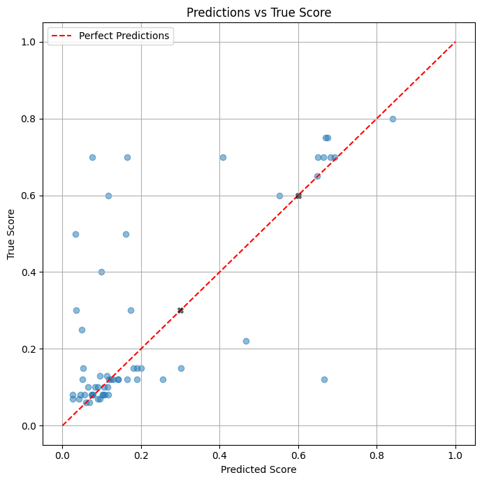

```
Tuning {'isBi': False, 'batch_size': 16, 'dropout': 0.6, 'lr': 0.0005, 'max_len': 90, 'n': 2, 'neurons': 256, 'output_dim': 128}...

Epoch 8: ReduceLROnPlateau reducing learning rate to 0.0002500000118743628.
val loss: 0.029875073581933975 , val mae : 0.1117333248257637, val rmse 0.1728440672159195
```

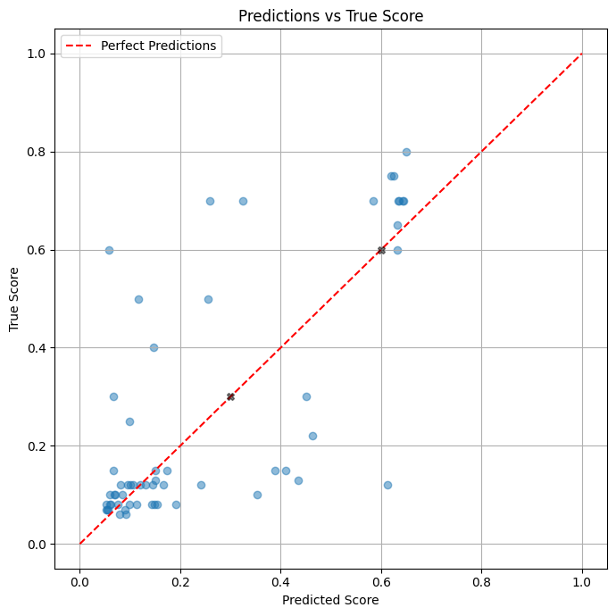

```
Tuning {'isBi': True, 'batch_size': 64, 'dropout': 0.5, 'lr': 0.0005, 'max_len': 100, 'n': 2, 'neurons': 64, 'output_dim': 256}...

Epoch 13: ReduceLROnPlateau reducing learning rate to 0.0002500000118743628.
val loss: 0.02424166165292263 , val mae : 0.0860847607254982, val rmse 0.15569733083248138
```

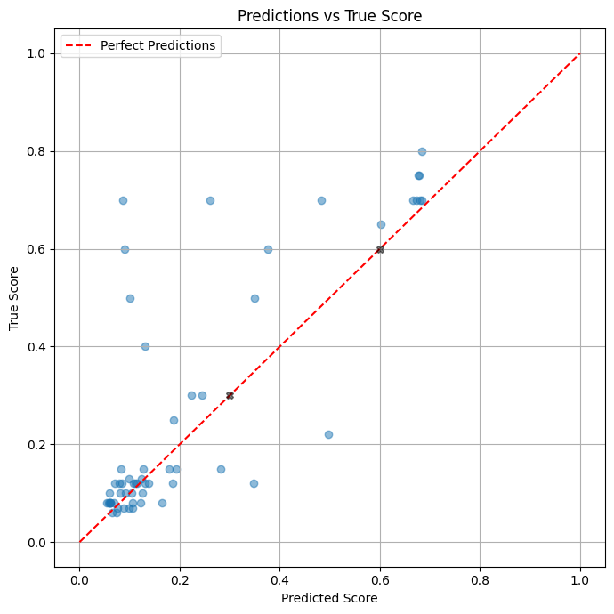

```
Tuning {'isBi': False, 'batch_size': 64, 'dropout': 0.5, 'lr': 0.0005, 'max_len': 100, 'n': 2, 'neurons': 64, 'output_dim': 256}...

Epoch 9: ReduceLROnPlateau reducing learning rate to 0.0002500000118743628.
val loss: 0.02018630877137184 , val mae : 0.08796265721321106, val rmse 0.14207853376865387
```

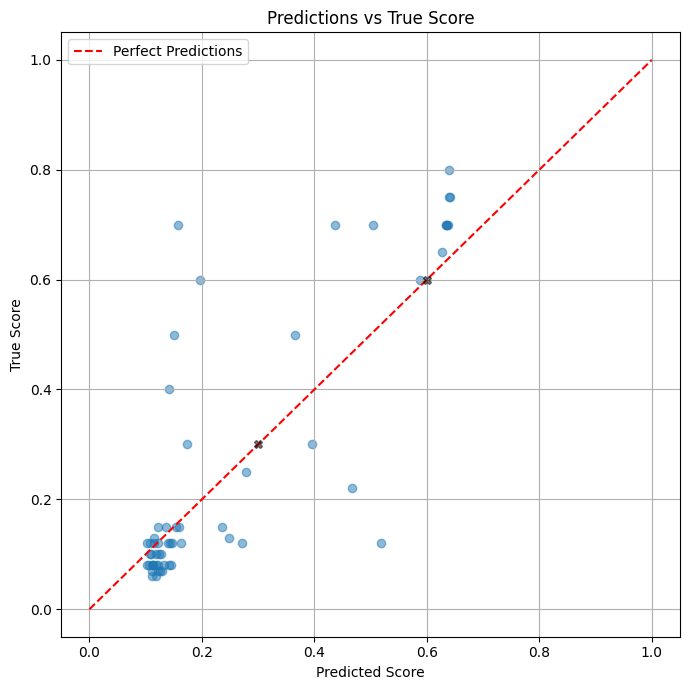

```
Tuning {'isBi': True, 'batch_size': 64, 'dropout': 0.7999999999999999, 'lr': 1e-05, 'max_len': 90, 'n': 2, 'neurons': 128, 'output_dim': 256}...

Epoch 6: ReduceLROnPlateau reducing learning rate to 4.999999873689376e-06.
val loss: 0.16134284436702728 , val mae : 0.37021440267562866, val rmse 0.4016750454902649

WARNING:tensorflow:5 out of the last 9 calls to <function Model.make_predict_function.<locals>.predict_function at 0x0000020C12D01B80> triggered tf.function retracing. Tracing is expensive and the excessive number of tracings could be due to (1) creating @tf.function repeatedly in a loop, (2) passin…
```

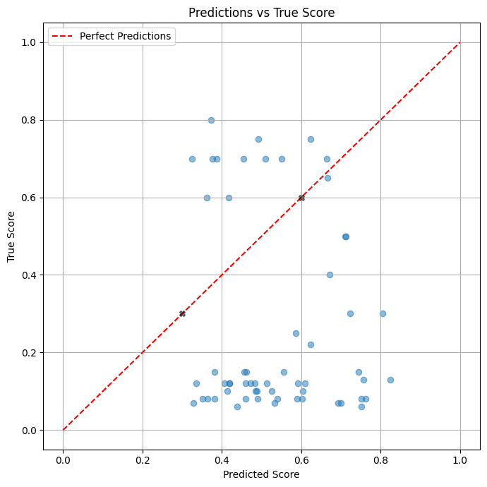

```
Tuning {'isBi': False, 'batch_size': 64, 'dropout': 0.7999999999999999, 'lr': 1e-05, 'max_len': 90, 'n': 2, 'neurons': 128, 'output_dim': 256}...

Epoch 36: ReduceLROnPlateau reducing learning rate to 4.999999873689376e-06.
val loss: 0.06017168611288071 , val mae : 0.169259175658226, val rmse 0.24529917538166046

WARNING:tensorflow:6 out of the last 11 calls to <function Model.make_predict_function.<locals>.predict_function at 0x0000020B55622700> triggered tf.function retracing. Tracing is expensive and the excessive number of tracings could be due to (1) creating @tf.function repeatedly in a loop, (2) passi…
```

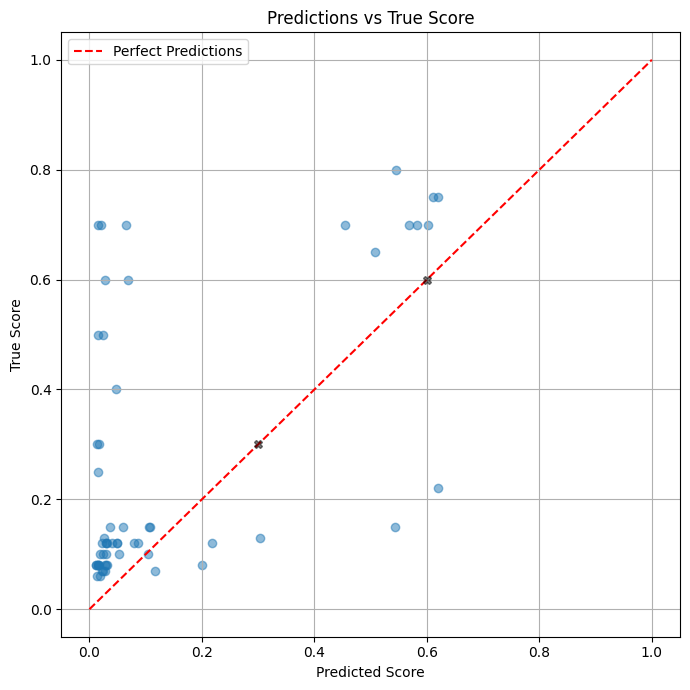

```
Tuning {'isBi': True, 'batch_size': 64, 'dropout': 0.6, 'lr': 0.001, 'max_len': 90, 'n': 2, 'neurons': 64, 'output_dim': 256}...

Epoch 7: ReduceLROnPlateau reducing learning rate to 0.0005000000237487257.
val loss: 0.03370432183146477 , val mae : 0.10588657110929489, val rmse 0.18358735740184784
```

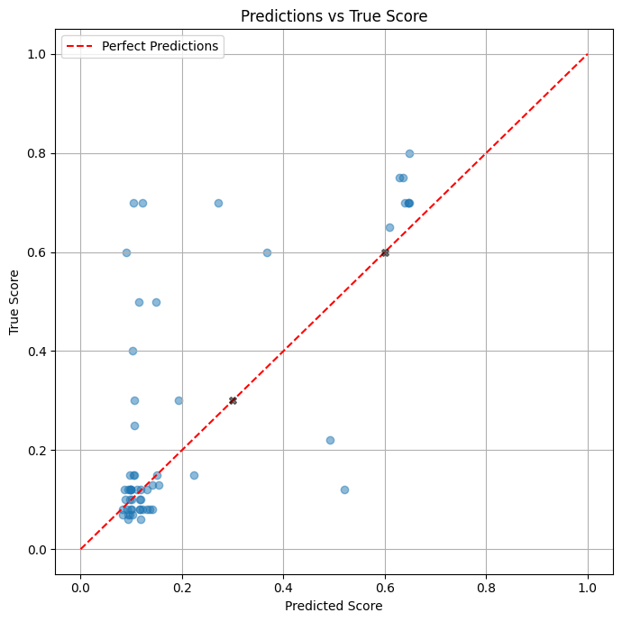

```
Tuning {'isBi': False, 'batch_size': 64, 'dropout': 0.6, 'lr': 0.001, 'max_len': 90, 'n': 2, 'neurons': 64, 'output_dim': 256}...

Epoch 11: ReduceLROnPlateau reducing learning rate to 0.0005000000237487257.
val loss: 0.03149242326617241 , val mae : 0.10300877690315247, val rmse 0.17746104300022125
```

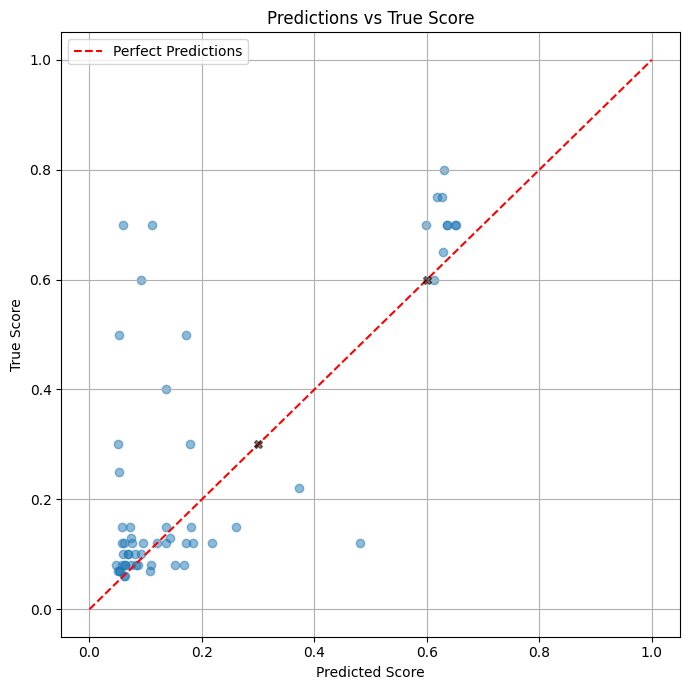

```
Tuning {'isBi': True, 'batch_size': 64, 'dropout': 0.7, 'lr': 0.001, 'max_len': 90, 'n': 4, 'neurons': 64, 'output_dim': 128}...

Epoch 10: ReduceLROnPlateau reducing learning rate to 0.0005000000237487257.
val loss: 0.03182046115398407 , val mae : 0.14350925385951996, val rmse 0.17838290333747864
```

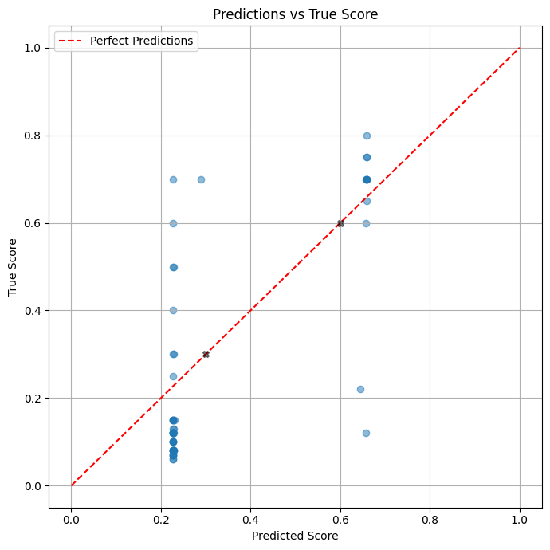

```
Tuning {'isBi': False, 'batch_size': 64, 'dropout': 0.7, 'lr': 0.001, 'max_len': 90, 'n': 4, 'neurons': 64, 'output_dim': 128}...

Epoch 16: ReduceLROnPlateau reducing learning rate to 0.0005000000237487257.
val loss: 0.02514578588306904 , val mae : 0.12729305028915405, val rmse 0.15857422351837158
```

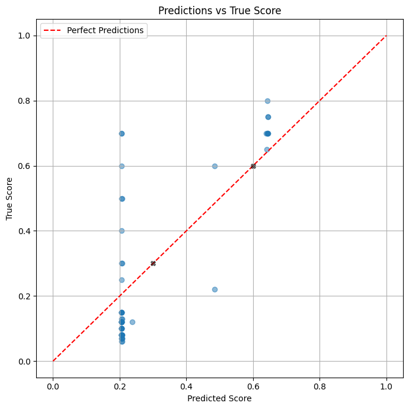

```
Tuning {'isBi': True, 'batch_size': 32, 'dropout': 0.7999999999999999, 'lr': 1e-05, 'max_len': 90, 'n': 2, 'neurons': 64, 'output_dim': 512}...
val loss: 0.04718548804521561 , val mae : 0.12956057488918304, val rmse 0.2172222137451172
```

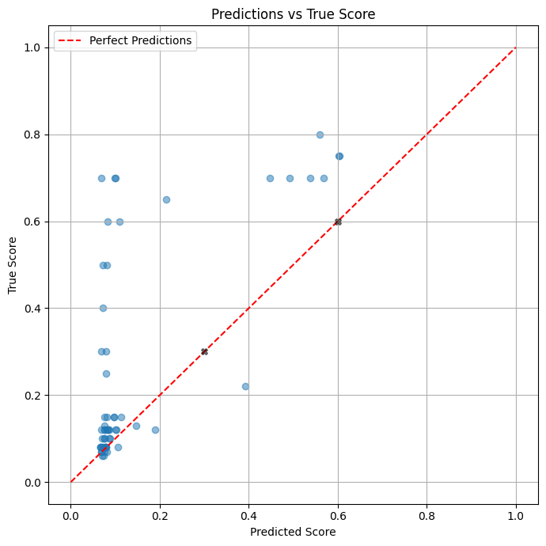

```
Tuning {'isBi': False, 'batch_size': 32, 'dropout': 0.7999999999999999, 'lr': 1e-05, 'max_len': 90, 'n': 2, 'neurons': 64, 'output_dim': 512}...

Epoch 25: ReduceLROnPlateau reducing learning rate to 4.999999873689376e-06.
val loss: 0.052066508680582047 , val mae : 0.14639747142791748, val rmse 0.2281808704137802
```

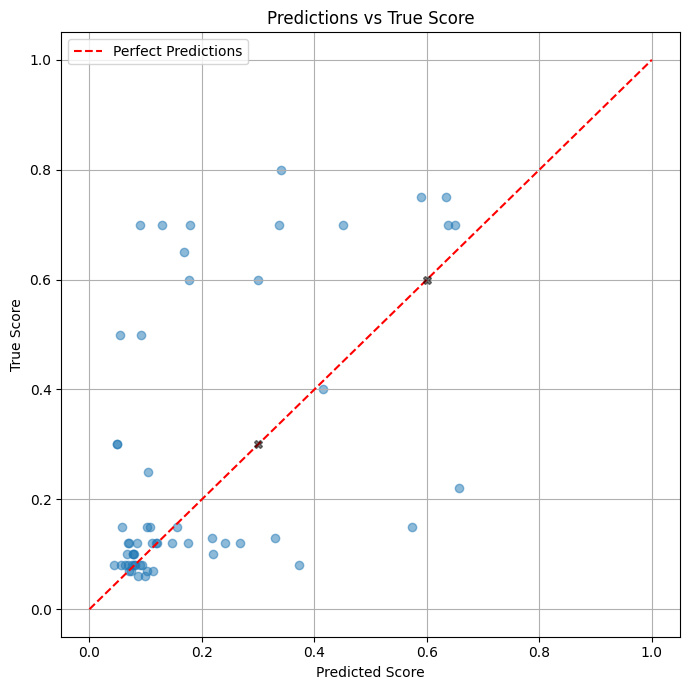

```
Tuning {'isBi': True, 'batch_size': 32, 'dropout': 0.7999999999999999, 'lr': 0.0001, 'max_len': 100, 'n': 4, 'neurons': 64, 'output_dim': 128}...

Epoch 7: ReduceLROnPlateau reducing learning rate to 4.999999873689376e-05.
val loss: 0.09314396232366562 , val mae : 0.29369330406188965, val rmse 0.3051949441432953
```

[18 more figures not shown]

```
Tuning {'isBi': True, 'batch_size': 64, 'dropout': 0.7, 'lr': 1e-05, 'max_len': 95, 'n': 4, 'neurons': 128, 'output_dim': 128}...
```

[output not shown]

[output cut: 54 more lines]

[output not shown]

```python
sequence_lens = [len(s) for s in sequences_train]
vocab_size = len(tokenizer.word_index) + 1

random.seed(888)

for base_params in random.sample(list(ParameterGrid(hyper_params)), 25):
  for isBi in [True, False]:
    try:
      # adding isBi
      params = {
        'isBi': isBi,
        **base_params
      }
      #padding sequences based on max len
      max_len = int(np.percentile(sequence_lens , params['max_len']))
      print(f'Tuning {params}...')

      padded_sequences = pad_sequences(sequences_train, padding='post', maxlen=max_len)
      padded_val_sequences = pad_sequences(sequences_val, padding='post' , maxlen=max_len)

      # Fit
      early_stop = EarlyStopping(patience=5, restore_best_weights = True , monitor='val_rmse' , mode='min')
      lr_reducer = ReduceLROnPlateau(
          monitor='val_rmse',
          factor=0.5,
          patience=5,
          min_lr=1e-6,
          verbose=1
      )

      model = create_model(**{k:v for k , v in params.items() if k not in ['batch_size', 'max_len']} , input_dim=vocab_size, input_length=max_len)

      history = model.fit(padded_sequences, train_data_df['Score'],
                epochs = 50,
                batch_size= params['batch_size'],
                verbose = 0,
                validation_data = (padded_val_sequences, y_val),
                callbacks = [ early_stop, lr_reducer ]
      )

      # evaluate and store
      val_loss , val_mae, val_rmse = model.evaluate(padded_val_sequences, y_val)
      print(f'val loss: {val_loss} , val mae : {val_mae}, val rmse {val_rmse}\n')

      val_losses.append(val_loss)
      val_rmses.append(val_rmse)
      fit_history.append(history.history)
      successful_params.append(params)

      # Plotting results
      y_pred = model.predict(padded_val_sequences)
      plt.figure(figsize=(7 , 7))
      plt.scatter(y_pred , y_val, alpha=0.5)
      plt.plot([0 , 1] , [0, 1] , 'r--', label='Perfect Predictions')
      plt.plot([0.6] , [0.6] , marker='X' , color='black' , alpha=0.5)
      plt.plot([0.3] , [0.3] , marker='X' , color='black' , alpha=0.5)
      plt.xlabel('Predicted Score')
      plt.ylabel('True Score')
      plt.title('Predictions vs True Score')
      plt.legend()
      plt.grid(True)
      plt.tight_layout()
      plt.show()

    except Exception as e:
      print(e)
      gc.collect()
      continue
```

I may have stopped the output if it has ran for too long/i have already seen a desired result

```python
val_maes = [min(history['val_mean_absolute_error']) for history in fit_history]
```

```python
results = pd.DataFrame({
 'fit_results': fit_history,
 'val_losses': val_losses,
 'val_rmses': val_rmses,
 'successful_params': successful_params
})
```

```python
with open(os.path.join('tuning_results' , 'rnn_tuning_v3_v2.pkl') , 'wb') as f:
  pickle.dump(results, f)
```

```python
best_params_index = np.argmin(val_rmses)

best_params = results['successful_params'][best_params_index]
best_loss = results['val_losses'][best_params_index]
best_rmse = results['val_rmses'][best_params_index]
best_mae =  val_maes[best_params_index]

print(best_params)
print(f'best mse: {best_loss}')
print(f'best rmse: {best_rmse}')
print(f'best mae: {best_mae}')
```

```
{'isBi': False, 'batch_size': 64, 'dropout': 0.5, 'lr': 0.0005, 'max_len': 100, 'n': 2, 'neurons': 64, 'output_dim': 256}
best mse: 0.02018630877137184
best rmse: 0.14207853376865387
best mae: 0.08382424712181091
```

##### Tuning Results Overview

While metrics give me a good overview of a model's performance, it is better for me to look directly at the plots instead

Below are the few that i feel are good to focus on:

1. 'Generic' Models (what most look like)

params:

```
{'isBi': False, 'batch_size': 32, 'dropout': 0.7999999999999999, 'lr': 0.0005, 'max_len': 90, 'n': 2, 'neurons': 128, 'output_dim': 512}
```

[figure not shown]

it shows that there is alot more positively predicted (like a bad positive precision)

This suggests that we can **include more negative and neutral data**

2. 'Best RMSE'

```
{'isBi': False, 'batch_size': 64, 'dropout': 0.5, 'lr': 0.0005, 'max_len': 100, 'n': 2, 'neurons': 64, 'output_dim': 256}
```

[figure not shown]

It is similar to the one above, but it seems to be better at predicting some neutral reviews **around 0.3**.

There are also **lesser false 'negative' predictions**, allowing me to just focus more on the neutral data

3. 'BiDirectional' of the above params

```
{'isBi': True, 'batch_size': 64, 'dropout': 0.5, 'lr': 0.0005, 'max_len': 100, 'n': 2, 'neurons': 64, 'output_dim': 256}
```

[figure not shown]

Graph is quite similiar to the one above

##### Conclusion / Model Improvement

It seems that my model is not ass good at predicting against the negative reviews.

It is also bad at predicting roughly the 0.3 reviews.

This suggests that i need to **Increase the amount of negative data**

```python
# The idea now to create more negative data from an 'artificial' adjective dictionary
# looking at currently negative adjectives
{k:v for k , v in adjective_list_dict.items() if v >= 0.6}
```

```
{'underwhelming': 0.6,
 'flat': 0.65,
 'complex': 0.65,
 'unsatisfying': 0.7,
 'weak': 0.75,
 'confusing': 0.7,
 'disappointing': 0.8,
 'challenging': 0.65,
 'missed': 0.75,
 'twist': 0.7,
 'ordinary': 0.65,
 'unconvincing': 0.75,
 'underwhelming moments': 0.6,
 'flat narrative': 0.65,
 'weak characterizations': 0.75,
 'confusing twists': 0.7,
 'disappointing resolution': 0.8,
 'challenging narrative': 0.65,
 'missed opportunity': 0.75,
 'ordinary plot': 0.65,
 'unconvincing acting': 0.75,
 'sad': 0.99,
 'unsatisfactory': 0.7,
 'stir': 0.8,
 'dizzy': 0.7}
```

```python
# we can add our own adjectives
new_negative_adjectives = {
    'mediocre': 0.6,
    'uninspired': 0.7,
    'predictable': 0.65,
    'bland': 0.6,
    'awkward': 0.7,
    'forgettable': 0.7,
    'overdone': 0.75,
    'cringeworthy': 0.8,
    'incoherent': 0.75,
    'forced': 0.7,
    'tedious': 0.8,
    'emotionless': 0.75,
    'stale': 0.65,
    'jarring': 0.7,
    'melodramatic': 0.7,
    'plodding': 0.7,
    'grating': 0.8,
    'tiresome': 0.75,
    'wooden': 0.7,
    'overacted': 0.8
}
```

```python
additional_negative_reviews = artificial_review_creation(new_negative_adjectives)
additional_negative_reviews
```

|  | Review | Score |
| --- | --- | --- |
| 0 | The movie was really mediocre | 0.6 |
| 1 | I found the scenese to be mediocre | 0.6 |
| 2 | Honestly, i really found the action scenes to ... | 0.6 |
| 3 | The experience was mediocre, i did not like it | 0.6 |
| 4 | The pacing felt mediocre throughout the film | 0.6 |
| ... | ... | ... |
| 415 | Some scenes were painfully overacted | 0.8 |
| 416 | Unfortunately, the entire movie felt overacted | 0.8 |
| 417 | The storytellling was overacted | 0.8 |
| 418 | The visuals were overacted | 0.8 |
| 419 | The film was overacted | 0.8 |

420 rows × 2 columns

```python
joined_additional_negative_reviews = join_reviews(additional_negative_reviews)
joined_additional_negative_reviews
```

|  | Review | Score |
| --- | --- | --- |
| 0 | The movie was really mediocre I found the scen... | 0.6 |
| 1 | The movie was really mediocre Honestly, i real... | 0.6 |
| 2 | The movie was really mediocre The experience w... | 0.6 |
| 3 | The movie was really mediocre The pacing felt ... | 0.6 |
| 4 | The movie was really mediocre Character develo... | 0.6 |
| ... | ... | ... |
| 87985 | Unfortunately, the entire movie felt overacted... | 0.8 |
| 87986 | Unfortunately, the entire movie felt overacted... | 0.8 |
| 87987 | The storytellling was overacted The visuals we... | 0.8 |
| 87988 | The storytellling was overacted The film was o... | 0.8 |
| 87989 | The visuals were overacted The film was overacted | 0.8 |

87990 rows × 2 columns

```python
additional_train_data_df = pd.concat([
  train_data_df,
  additional_negative_reviews,
  joined_additional_negative_reviews
], ignore_index=True)
```

Re-evaluate

We can try both BI and non-BI for the best model

```python
tokenizer = Tokenizer(oov_token="<OOV>")
tokenizer.fit_on_texts(additional_train_data_df['Review'])

sequences_train = tokenizer.texts_to_sequences(additional_train_data_df['Review'])
sequences_val = tokenizer.texts_to_sequences(val_data_df['Review'])
sequences_test = tokenizer.texts_to_sequences(test_data_df['Review'])
```

```
Tuning {'isBi': False, 'batch_size': 64, 'dropout': 0.5, 'lr': 0.0005, 'max_len': 100, 'n': 2, 'neurons': 64, 'output_dim': 256}...
Epoch 13: ReduceLROnPlateau reducing learning rate to 0.0002500000118743628.
val loss: 0.03526705875992775 , val mae : 0.10294365882873535, val rmse 0.1877952516078949
```

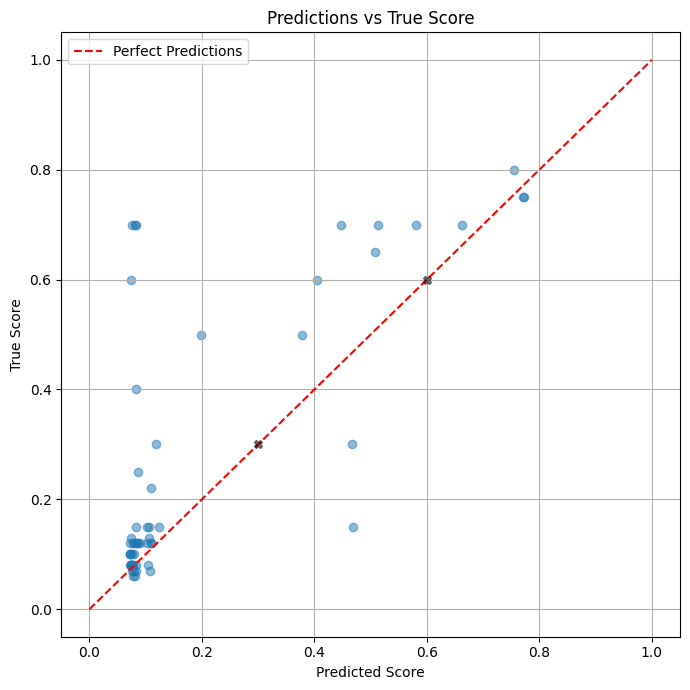

```python
params = {'isBi': False, 'batch_size': 64, 'dropout': 0.5, 'lr': 0.0005, 'max_len': 100, 'n': 2, 'neurons': 64, 'output_dim': 256}

#padding sequences based on max len
max_len = int(np.percentile(sequence_lens , params['max_len']))
print(f'Tuning {params}...')

padded_sequences = pad_sequences(sequences_train, padding='post', maxlen=max_len)
padded_val_sequences = pad_sequences(sequences_val, padding='post' , maxlen=max_len)

# Fit
early_stop = EarlyStopping(patience=5, restore_best_weights = True , monitor='val_rmse' , mode='min')
lr_reducer = ReduceLROnPlateau(
  monitor='val_rmse',
  factor=0.5,
  patience=5,
  min_lr=1e-6,
  verbose=1
)
model_checkpoint = ModelCheckpoint(filepath=os.path.join('stored_models' , f'rnn_best_weights_v3.h5'),
                                    monitor='val_rmse',
                                    save_best_only=True,
                                    save_weight_only=True,
                                    mode='min'
                                   )


model = create_model(**{k:v for k , v in params.items() if k not in ['batch_size', 'max_len']} , input_dim=vocab_size, input_length=max_len)
history = model.fit(padded_sequences, additional_train_data_df['Score'],
        epochs = 50,
        batch_size= params['batch_size'],
        verbose = 1,
        validation_data = (padded_val_sequences, y_val),
        callbacks = [ early_stop, lr_reducer , model_checkpoint]
)


# evaluate and store
val_loss , val_mae, val_rmse = model.evaluate(padded_val_sequences, y_val)
print(f'val loss: {val_loss} , val mae : {val_mae}, val rmse {val_rmse}\n')

# Plotting results
y_pred = model.predict(padded_val_sequences)
plt.figure(figsize=(7 , 7))
plt.scatter(y_pred , y_val, alpha=0.5)
plt.plot([0 , 1] , [0, 1] , 'r--', label='Perfect Predictions')
plt.plot([0.6] , [0.6] , marker='X' , color='black' , alpha=0.5)
plt.plot([0.3] , [0.3] , marker='X' , color='black' , alpha=0.5)
plt.xlabel('Predicted Score')
plt.ylabel('True Score')
plt.title('Predictions vs True Score')
plt.legend()
plt.grid(True)
plt.tight_layout()
plt.show()
```

```
Tuning {'isBi': True, 'batch_size': 64, 'dropout': 0.5, 'lr': 0.0005, 'max_len': 100, 'n': 2, 'neurons': 64, 'output_dim': 256}...
Epoch 30: ReduceLROnPlateau reducing learning rate to 0.0002500000118743628.
val loss: 0.03482063487172127 , val mae : 0.10395379364490509, val rmse 0.1866028755903244
```

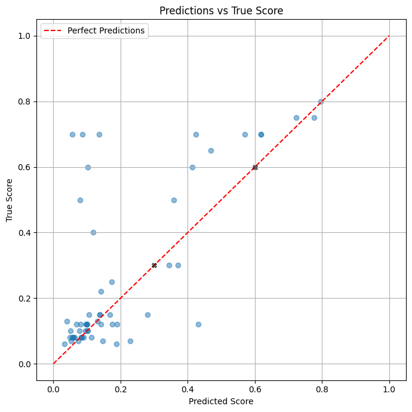

```python
params = {'isBi': True, 'batch_size': 64, 'dropout': 0.5, 'lr': 0.0005, 'max_len': 100, 'n': 2, 'neurons': 64, 'output_dim': 256}

#padding sequences based on max len
max_len = int(np.percentile(sequence_lens , params['max_len']))
print(f'Tuning {params}...')

padded_sequences = pad_sequences(sequences_train, padding='post', maxlen=max_len)
padded_val_sequences = pad_sequences(sequences_val, padding='post' , maxlen=max_len)

# Fit
early_stop = EarlyStopping(patience=5, restore_best_weights = True , monitor='val_rmse' , mode='min')
lr_reducer = ReduceLROnPlateau(
  monitor='val_rmse',
  factor=0.5,
  patience=5,
  min_lr=1e-6,
  verbose=1
)
model_checkpoint = ModelCheckpoint(filepath=os.path.join('stored_models' , f'rnn_best_weights_v3_Bidirectional.h5'),
                                    monitor='val_rmse',
                                    save_best_only=True,
                                    save_weight_only=True,
                                    mode='min'
                                   )


model = create_model(**{k:v for k , v in params.items() if k not in ['batch_size', 'max_len']} , input_dim=vocab_size, input_length=max_len)
history = model.fit(padded_sequences, additional_train_data_df['Score'],
        epochs = 50,
        batch_size= params['batch_size'],
        verbose = 1,
        validation_data = (padded_val_sequences, y_val),
        callbacks = [ early_stop, lr_reducer , model_checkpoint]
)


# evaluate and store
val_loss , val_mae, val_rmse = model.evaluate(padded_val_sequences, y_val)
print(f'val loss: {val_loss} , val mae : {val_mae}, val rmse {val_rmse}\n')

val_losses.append(val_loss)
val_rmses.append(val_rmse)
fit_history.append(history.history)
successful_params.append(params)

# Plotting results
y_pred = model.predict(padded_val_sequences)
plt.figure(figsize=(7 , 7))
plt.scatter(y_pred , y_val, alpha=0.5)
plt.plot([0 , 1] , [0, 1] , 'r--', label='Perfect Predictions')
plt.plot([0.6] , [0.6] , marker='X' , color='black' , alpha=0.5)
plt.plot([0.3] , [0.3] , marker='X' , color='black' , alpha=0.5)
plt.xlabel('Predicted Score')
plt.ylabel('True Score')
plt.title('Predictions vs True Score')
plt.legend()
plt.grid(True)
plt.tight_layout()
plt.show()
```

SO i will attempt it with the stopwords removed as well

```python
# Removing Stopwords
additional_train_data_df['Review'] = additional_train_data_df['Review'].apply(remove_stopwords).apply(clean_text)
```

```python
tokenizer_stopwords = Tokenizer(oov_token="<OOV>")
tokenizer_stopwords.fit_on_texts(additional_train_data_df['Review'])

sequences_train = tokenizer_stopwords.texts_to_sequences(additional_train_data_df['Review'])
sequences_val = tokenizer_stopwords.texts_to_sequences(val_data_df['Review'])
sequences_test = tokenizer_stopwords.texts_to_sequences(test_data_df['Review'])
```

```
Tuning {'isBi': True, 'batch_size': 64, 'dropout': 0.5, 'lr': 0.0005, 'max_len': 100, 'n': 2, 'neurons': 64, 'output_dim': 256}...
Epoch 11: ReduceLROnPlateau reducing learning rate to 0.0002500000118743628.
val loss: 0.014916498214006424 , val mae : 0.07489095628261566, val rmse 0.12213311344385147
```

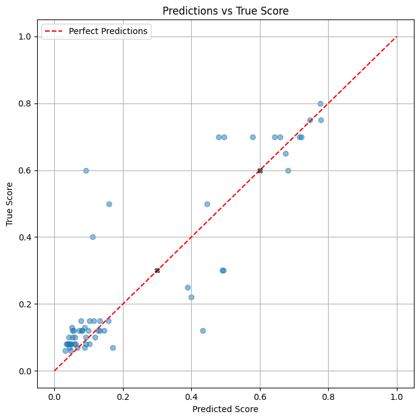

```python
params = {'isBi': True, 'batch_size': 64, 'dropout': 0.5, 'lr': 0.0005, 'max_len': 100, 'n': 2, 'neurons': 64, 'output_dim': 256}

#padding sequences based on max len
max_len = int(np.percentile(sequence_lens , params['max_len']))
print(f'Tuning {params}...')

padded_sequences = pad_sequences(sequences_train, padding='post', maxlen=max_len)
padded_val_sequences = pad_sequences(sequences_val, padding='post' , maxlen=max_len)

# Fit
early_stop = EarlyStopping(patience=5, restore_best_weights = True , monitor='val_rmse' , mode='min')
lr_reducer = ReduceLROnPlateau(
  monitor='val_rmse',
  factor=0.5,
  patience=5,
  min_lr=1e-6,
  verbose=1
)
model_checkpoint = ModelCheckpoint(filepath=os.path.join('stored_models' , f'rnn_best_weights_v3_Bidirectional_Stopwords_removed.h5'),
                                    monitor='val_rmse',
                                    save_best_only=True,
                                    save_weight_only=True,
                                    mode='min'
                                   )


model = create_model(**{k:v for k , v in params.items() if k not in ['batch_size', 'max_len']} , input_dim=vocab_size, input_length=max_len)
history = model.fit(padded_sequences, additional_train_data_df['Score'],
        epochs = 50,
        batch_size= params['batch_size'],
        verbose = 1,
        validation_data = (padded_val_sequences, y_val),
        callbacks = [ early_stop, lr_reducer , model_checkpoint]
)


# evaluate and store
val_loss , val_mae, val_rmse = model.evaluate(padded_val_sequences, y_val)
print(f'val loss: {val_loss} , val mae : {val_mae}, val rmse {val_rmse}\n')

val_losses.append(val_loss)
val_rmses.append(val_rmse)
fit_history.append(history.history)
successful_params.append(params)

# Plotting results
y_pred = model.predict(padded_val_sequences)
plt.figure(figsize=(7 , 7))
plt.scatter(y_pred , y_val, alpha=0.5)
plt.plot([0 , 1] , [0, 1] , 'r--', label='Perfect Predictions')
plt.plot([0.6] , [0.6] , marker='X' , color='black' , alpha=0.5)
plt.plot([0.3] , [0.3] , marker='X' , color='black' , alpha=0.5)
plt.xlabel('Predicted Score')
plt.ylabel('True Score')
plt.title('Predictions vs True Score')
plt.legend()
plt.grid(True)
plt.tight_layout()
plt.show()
```

##### Conclusion

It seems that the 'stopwords-removed' dataset worked the best.

It also performed very well with the **Bidirectional LSTM**.

Increasing the negative dataset allowed for my model to **predict alot better on negative reviews**

**However** It seems that the neutral dataset has **little effect** on the prediction of neutral reviews.

Final params:

| Parameter | Value |
| --- | --- |
| `isBi` | `True` |
| `batch_size` | `64` |
| `dropout` | `0.5` |
| `lr` | `0.0005` |
| `max_len` | `100` |
| `n` | `2` |
| `neurons` | `64` |
| `output_dim` | `256` |

##### Final Prediction on Test

```
testing...
val loss: 0.014916498214006424 , val mae : 0.07489095628261566, val rmse 0.12213311344385147

test loss: 0.03202114999294281 , test mae : 0.10263440012931824, test rmse 0.17894454300403595
```

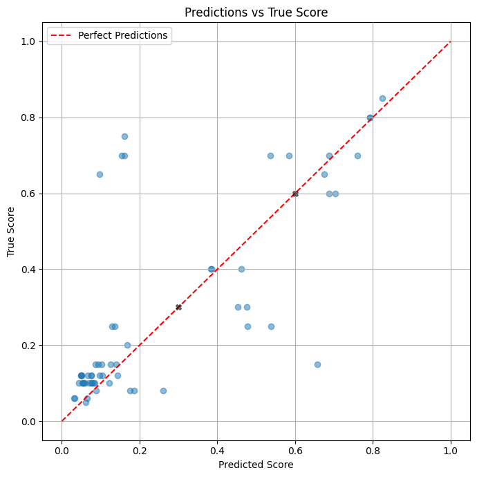

```python
params = {'isBi': True, 'batch_size': 64, 'dropout': 0.5, 'lr': 0.0005, 'max_len': 100, 'n': 2, 'neurons': 64, 'output_dim': 256}

#padding sequences based on max len
max_len = int(np.percentile(sequence_lens , params['max_len']))
print(f'testing...')

padded_sequences = pad_sequences(sequences_train, padding='post', maxlen=max_len)
padded_val_sequences = pad_sequences(sequences_val, padding='post' , maxlen=max_len)
padded_test_sequences = pad_sequences(sequences_test, padding='post' , maxlen=max_len)

# Fit
model = create_model(**{k:v for k , v in params.items() if k not in ['batch_size', 'max_len']} , input_dim=vocab_size, input_length=max_len)
model.load_weights(os.path.join('stored_models' , f'rnn_best_weights_v3_Bidirectional_Stopwords_removed.h5'))


# evaluate and store
val_loss , val_mae, val_rmse = model.evaluate(padded_val_sequences, y_val)
print(f'val loss: {val_loss} , val mae : {val_mae}, val rmse {val_rmse}\n')

test_loss , test_mae, test_rmse = model.evaluate(padded_test_sequences, y_test)
print(f'test loss: {test_loss} , test mae : {test_mae}, test rmse {test_rmse}\n')

# Plotting results
y_pred = model.predict(padded_test_sequences)
plt.figure(figsize=(7 , 7))
plt.scatter(y_pred , y_test, alpha=0.5)
plt.plot([0 , 1] , [0, 1] , 'r--', label='Perfect Predictions')
plt.plot([0.6] , [0.6] , marker='X' , color='black' , alpha=0.5)
plt.plot([0.3] , [0.3] , marker='X' , color='black' , alpha=0.5)
plt.xlabel('Predicted Score')
plt.ylabel('True Score')
plt.title('Predictions vs True Score')
plt.legend()
plt.grid(True)
plt.tight_layout()
plt.show()
```